```python
import numpy as np
import pandas as pd
```

# numpy

```python
np.__version__
```

```
'1.23.5'
```

numpy中的数据存储是array, array要求数据类型是一样的，这和python中的list不同

```python
np.array([1,1.0,'2']) # 强制转换成同一种类型
```

```
array(['1', '1.0', '2'], dtype='<U32')
```

```python
np.array([1,1.0,'2'],dtype=int)
```

```
array([1, 1, 2])
```

## generating Array

```python
np.ones((3,5))
```

```
array([[1., 1., 1., 1., 1.],
       [1., 1., 1., 1., 1.],
       [1., 1., 1., 1., 1.]])
```

```python
np.full((3,5),1.231)
```

```
array([[1.231, 1.231, 1.231, 1.231, 1.231],
       [1.231, 1.231, 1.231, 1.231, 1.231],
       [1.231, 1.231, 1.231, 1.231, 1.231]])
```

```python
np.arange(0, 20)
```

```
array([ 0,  1,  2,  3,  4,  5,  6,  7,  8,  9, 10, 11, 12, 13, 14, 15, 16,
       17, 18, 19])
```

```python
np.random.normal(0, 1, (3,3))
```

```
array([[ 0.11949003,  0.51600352, -0.60939972],
       [-0.44918345,  0.80383762, -0.20336444],
       [ 0.20335392, -1.23692957, -1.40778524]])
```

```python
np.eye(3)
```

```
array([[1., 0., 0.],
       [0., 1., 0.],
       [0., 0., 1.]])
```

```python
np.tile?
```

[output not shown]

[output cut: 12 more lines]

[output not shown]

```python
np.tile(10,3)
```

```
array([10, 10, 10])
```

```python
np.tile([1,2,3],3)
```

```
array([1, 2, 3, 1, 2, 3, 1, 2, 3])
```

```python
np.repeat?
```

```
Signature: np.repeat(a, repeats, axis=None)
Docstring:
Repeat elements of an array.

Parameters
----------
a : array_like
    Input array.
repeats : int or array of ints
    The number of repetitions for each element.  `repeats` is broadcasted
    to fit the shape of the given axis.
axis : int, optional
    The axis along which to repeat values.  By default, use the
    flattened input array, and return a flat output array.

Returns
-------
repeated_array : ndarray
    Output array which has the same shape as `a`, except along
    the given axis.

See Also
--------
tile : Tile an array.
unique : Find the unique elements of an array.

Examples
--------
>>> np.repeat(3, 4)
array([3, 3, 3, 3])
>>> x = np.array([[1,2],[3,4]])
>>> np.repeat(x, 2)
array([1, 1, 2, 2, 3, 3, 4, 4])
>>> np.repeat(x, 3, axis=1)
array([[1, 1, 1, 2, 2, 2],
       [3, 3, 3, 4, 4, 4]])
>>> np.repeat(x, [1, 2], axis=0)
array([[1, 2],
       [3, 4],
       [3, 4]])
File:      ~/opt/anaconda3/lib/python3.9/site-packages/numpy/core/fromnumeric.py
Type:      function
```

```python
np.asarray([1,2,3]).repeat(3)
```

```
array([1, 1, 1, 2, 2, 2, 3, 3, 3])
```

## Array indexing and slicing

```python
a = np.random.normal(0, 1, (3,3))
a
```

```
array([[-1.26401894,  0.13314849, -0.81723518],
       [-0.35654833,  1.03394826,  0.05554441],
       [-0.22990499,  0.14560186, -0.26441533]])
```

```python
a[0,1]
```

```
0.1331484866845464
```

```python
a[0:2]
```

```
array([[-1.26401894,  0.13314849, -0.81723518],
       [-0.35654833,  1.03394826,  0.05554441]])
```

```python
a[0:2,1]
```

```
array([0.13314849, 1.03394826])
```

```python
a[0,1] = 1000
```

```python
a
```

```
array([[-1.26401894e+00,  1.00000000e+03, -8.17235181e-01],
       [-3.56548330e-01,  1.03394826e+00,  5.55444060e-02],
       [-2.29904987e-01,  1.45601862e-01, -2.64415325e-01]])
```

```python
a[0:3:2]
```

```
array([[-1.26401894e+00,  1.00000000e+03, -8.17235181e-01],
       [-2.29904987e-01,  1.45601862e-01, -2.64415325e-01]])
```

## Array concatenation

```python
x = np.array([1, 2, 3])
y = np.array([3, 2, 1])
z = [21,21,21]
np.concatenate([x,y,z])
```

```
array([ 1,  2,  3,  3,  2,  1, 21, 21, 21])
```

```python
a1 = np.ones((3,3))
a2 = np.random.normal(0, 1, (3,3))
```

```python
a1
```

```
array([[1., 1., 1.],
       [1., 1., 1.],
       [1., 1., 1.]])
```

```python
a2
```

```
array([[-0.48831842, -0.30504266,  0.82149508],
       [-1.71501757, -0.41102703, -0.38721744],
       [ 1.20687861,  0.0802707 , -1.83544937]])
```

```python
np.concatenate([a1,a2])
```

```
array([[ 1.        ,  1.        ,  1.        ],
       [ 1.        ,  1.        ,  1.        ],
       [ 1.        ,  1.        ,  1.        ],
       [-0.48831842, -0.30504266,  0.82149508],
       [-1.71501757, -0.41102703, -0.38721744],
       [ 1.20687861,  0.0802707 , -1.83544937]])
```

```python
np.concatenate([a1,a2], axis=1)
```

```
array([[ 1.        ,  1.        ,  1.        , -0.48831842, -0.30504266,
         0.82149508],
       [ 1.        ,  1.        ,  1.        , -1.71501757, -0.41102703,
        -0.38721744],
       [ 1.        ,  1.        ,  1.        ,  1.20687861,  0.0802707 ,
        -1.83544937]])
```

## Array reshaping

```python
a1 = np.array(range(10))
a1[0:3]
```

```
array([0, 1, 2])
```

```python
a1
```

```
array([0, 1, 2, 3, 4, 5, 6, 7, 8, 9])
```

```python
a1.shape
```

```
(10,)
```

```python
a1 = a1.reshape((10,1))
```

```python
a1.shape
```

```
(10, 1)
```

```python
a1
```

```
array([[0],
       [1],
       [2],
       [3],
       [4],
       [5],
       [6],
       [7],
       [8],
       [9]])
```

```python
a1 = a1.reshape((1,10))
```

```python
a1.shape
```

```
(1, 10)
```

```python
a1
```

```
array([[0, 1, 2, 3, 4, 5, 6, 7, 8, 9]])
```

```python
a1.reshape((2,6))
```

```
---------------------------------------------------------------------------
ValueError                                Traceback (most recent call last)
Cell In[39], line 1
----> 1 a1.reshape((2,6))

ValueError: cannot reshape array of size 10 into shape (2,6)
```

```python
a1 = a1.reshape((2,5))
```

```python
a1
```

```
array([[0, 1, 2, 3, 4],
       [5, 6, 7, 8, 9]])
```

```python
a2 = np.array(range(10,20)).reshape((2,5))
```

```python
a2
```

```
array([[10, 11, 12, 13, 14],
       [15, 16, 17, 18, 19]])
```

```python
a1
```

```
array([[0, 1, 2, 3, 4],
       [5, 6, 7, 8, 9]])
```

```python
np.vstack([a1,a2])
```

```
array([[ 0,  1,  2,  3,  4],
       [ 5,  6,  7,  8,  9],
       [10, 11, 12, 13, 14],
       [15, 16, 17, 18, 19]])
```

```python
np.hstack([a1,a2])
```

```
array([[ 0,  1,  2,  3,  4, 10, 11, 12, 13, 14],
       [ 5,  6,  7,  8,  9, 15, 16, 17, 18, 19]])
```

## Vectorized manipulations

**做numpy和pandas操作时的一个原则：能用向量操作尽量用向量操作，速度最快。尽量避免写元素的循环**

```python
a1 + 1000
```

```
array([[1000, 1001, 1002, 1003, 1004],
       [1005, 1006, 1007, 1008, 1009]])
```

```python
a1 * a2
```

```
array([[  0,  11,  24,  39,  56],
       [ 75,  96, 119, 144, 171]])
```

```python
list1 = [1,2,3] # some manipulations is not possible with raw python
list2 = [4,5,6]
```

```python
list1 * list2
```

```
---------------------------------------------------------------------------
TypeError                                 Traceback (most recent call last)
Cell In[50], line 1
----> 1 list1 * list2

TypeError: can't multiply sequence by non-int of type 'list'
```

```python
list1 + list2
```

```
[1, 2, 3, 4, 5, 6]
```

```python
x = np.array([[1, 2, 3], [4, 5, 6]])
x.ravel()
```

```
array([1, 2, 3, 4, 5, 6])
```

```python
x.ravel(order='F')
```

```
array([1, 4, 2, 5, 3, 6])
```

## Calculations with numpy

```python
a1
```

```
array([[0, 1, 2, 3, 4],
       [5, 6, 7, 8, 9]])
```

```python
a1.max()
```

```
9
```

axis: 0，从上往下（跨行）。1，从左往右（跨列）

也适用于pandas

```python
a1.max(axis=1)
```

```
array([4, 9])
```

```python
a1.max(axis=0)
```

```
array([5, 6, 7, 8, 9])
```

```python
a1.sum()
```

```
45
```

```python
a1.sum(axis=0)
```

```
array([ 5,  7,  9, 11, 13])
```

```python
a1.sum(axis=1)
```

```
array([10, 35])
```

```python
a1.mean()
```

```
4.5
```

```python
a1
```

```
array([[0, 1, 2, 3, 4],
       [5, 6, 7, 8, 9]])
```

```python
a1.mean(axis=1)
```

```
array([2., 7.])
```

```python
a1.mean(axis=0)
```

```
array([2.5, 3.5, 4.5, 5.5, 6.5])
```

## Masked arrays

Mask 把 array 的一部分“挡住”，来阻止其他的函数对其进行操作。这在有的时候挺有用

```python
import numpy.ma as ma
```

```python
x = np.array([1,2,3,-1,4])
```

```python
mx = ma.masked_array(x, mask=[0,0,0,1,0])
```

```python
mx
```

```
masked_array(data=[1, 2, 3, --, 4],
             mask=[False, False, False,  True, False],
       fill_value=999999)
```

```python
mx.mean()
```

```
2.5
```

```python
# -999 as an invalid value, as sometimes seen in some databases
a = np.array([0,1,2,-999])
ma.masked_values(a, -999)
```

```
masked_array(data=[0, 1, 2, --],
             mask=[False, False, False,  True],
       fill_value=-999)
```

# pandas

- 2008年由AQR工作的 Wes McKinney创始
- 受到R中data.frame的影响很大
- 其目的是为python提供一个便于操作金融数据的框架
- 名称来源：panel data analysis
- 已广泛应用于各类表格类(tabular)的数据操作

## Create a data frame

```python
df = pd.DataFrame({'name':[chr(i) for i in range(ord('a'),ord('z')+1)],
                   'value':range(26)}) # string.ascii_lowercase provides the alphabet too.
df
```

|  | name | value |
| --- | --- | --- |
| 0 | a | 0 |
| 1 | b | 1 |
| 2 | c | 2 |
| 3 | d | 3 |
| 4 | e | 4 |
| 5 | f | 5 |
| 6 | g | 6 |
| 7 | h | 7 |
| 8 | i | 8 |
| 9 | j | 9 |
| 10 | k | 10 |
| 11 | l | 11 |
| 12 | m | 12 |
| 13 | n | 13 |
| 14 | o | 14 |
| 15 | p | 15 |
| 16 | q | 16 |
| 17 | r | 17 |
| 18 | s | 18 |
| 19 | t | 19 |
| 20 | u | 20 |
| 21 | v | 21 |
| 22 | w | 22 |
| 23 | x | 23 |
| 24 | y | 24 |
| 25 | z | 25 |

```python
data = [['tom', 10], ['nick', 15], ['juli', 14]]
df = pd.DataFrame(data, columns = ['Name', 'Age'], index=['a','b','c'])
df
```

|  | Name | Age |
| --- | --- | --- |
| a | tom | 10 |
| b | nick | 15 |
| c | juli | 14 |

### Quick production of dataframe examples with `pandas._testing`

```python
import pandas._testing as tm
```

```python
dir(tm)
```

[output not shown]

[output cut: 133 more lines]

[output not shown]

```python
tm.makeDataFrame()
```

|  | A | B | C | D |
| --- | --- | --- | --- | --- |
| cZJYRFBjsZ | 1.017466 | 0.408885 | 0.322214 | 0.054719 |
| lLVrbjR6Vr | 0.033257 | 0.616884 | -1.040222 | -1.780187 |
| eLUp4PALTt | 2.656438 | 0.640599 | 0.261727 | -0.520845 |
| BzoGUejyQV | -0.828406 | 0.037566 | -0.536611 | 0.292041 |
| UfVsUDv70f | -0.563905 | -0.634545 | 0.429127 | 0.117443 |
| ZCvtoS4VLQ | 0.455937 | -1.760947 | 0.924035 | -1.096260 |
| ZCnKayvc0L | 1.224438 | -0.215123 | -0.083788 | -0.436338 |
| trYE7TVe9q | -0.316089 | 0.210430 | 1.309266 | -0.360450 |
| 0BjFKt4A4R | 0.878868 | 0.925385 | -1.945032 | 0.580221 |
| g5R8etUU47 | -1.324358 | 0.879758 | -0.075207 | -1.033363 |
| WyUH5ihfxA | -0.505695 | -0.562268 | -1.301524 | -2.136327 |
| lgaFDVh71E | -2.878787 | -2.156321 | -0.753986 | 1.287103 |
| MKe0DW9Aco | 0.875395 | 0.718449 | 0.098643 | 1.016631 |
| Fu5VORq3HB | 0.196059 | -1.715751 | 0.377394 | -0.425211 |
| 4awpGNwhCr | -1.430431 | 1.107052 | 0.351579 | 0.038333 |
| abWuxFTgak | 1.134595 | -0.654446 | -1.780598 | 0.475640 |
| LdGjWdsrap | 1.052956 | -0.321872 | 1.515367 | 0.178291 |
| haSxy2J3H7 | 0.382825 | 1.793814 | 0.452140 | -0.396571 |
| QKkLEY5HdO | -1.091404 | 1.648727 | 1.189487 | 0.734657 |
| Na4icA12zD | 1.463891 | 0.415739 | 1.857051 | -0.437692 |
| Xrx5Xz8pHm | 1.010493 | 0.532272 | 0.981934 | -1.179908 |
| eXHd43VLjJ | 0.301460 | -0.344703 | 0.725504 | -0.505409 |
| i0bUrWpwuC | 0.818570 | 1.907338 | 1.997379 | -0.226253 |
| jBFWDXzj9J | 1.070393 | 0.019434 | -2.291473 | 0.049770 |
| eoQ1Xto9xt | 1.038056 | 0.386739 | -1.145852 | -0.691260 |
| MX1ffAFzk5 | 1.050974 | -0.011987 | 1.075066 | 0.700000 |
| v1bcFWTZHT | 1.132417 | -0.014813 | 0.277577 | 0.020498 |
| SrJSnSQKf6 | 2.308104 | 0.008408 | -0.900696 | 0.515424 |
| uH7sGOyWjP | -0.144934 | -0.138548 | 0.331670 | -0.315515 |
| dHDDaETSMu | 0.352889 | -0.455680 | 1.487833 | 1.291541 |

```python
tm.makeMixedDataFrame()
```

|  | A | B | C | D |
| --- | --- | --- | --- | --- |
| 0 | 0.0 | 0.0 | foo1 | 2009-01-01 |
| 1 | 1.0 | 1.0 | foo2 | 2009-01-02 |
| 2 | 2.0 | 0.0 | foo3 | 2009-01-05 |
| 3 | 3.0 | 1.0 | foo4 | 2009-01-06 |
| 4 | 4.0 | 0.0 | foo5 | 2009-01-07 |

```python
df1 = tm.makeTimeDataFrame()
df1
```

|  | A | B | C | D |
| --- | --- | --- | --- | --- |
| 2000-01-03 | -0.256639 | -0.360026 | 0.781808 | 2.365876 |
| 2000-01-04 | -0.441481 | -0.416982 | -0.085862 | 1.215792 |
| 2000-01-05 | 0.687317 | -0.840725 | 0.368144 | -0.604941 |
| 2000-01-06 | 0.524671 | 0.562214 | 1.348964 | -0.017417 |
| 2000-01-07 | 1.436570 | -1.263538 | -0.035792 | 0.671226 |
| 2000-01-10 | 0.047872 | 0.716265 | 0.640712 | -1.106825 |
| 2000-01-11 | 0.930656 | -1.086892 | -0.519984 | -0.337252 |
| 2000-01-12 | 0.907508 | -0.841800 | 1.025432 | -0.862827 |
| 2000-01-13 | 0.539813 | 1.520450 | 0.024358 | 1.493062 |
| 2000-01-14 | 0.157760 | -0.282024 | -0.499526 | -0.562860 |
| 2000-01-17 | 0.309461 | -2.399618 | -0.353253 | 1.401097 |
| 2000-01-18 | 0.010488 | -0.879997 | -0.551815 | -0.522194 |
| 2000-01-19 | 1.299948 | 0.264738 | -0.883126 | 0.356829 |
| 2000-01-20 | -1.287793 | -0.818199 | -1.101668 | -0.558555 |
| 2000-01-21 | -0.100412 | 0.177467 | 1.180741 | 0.013179 |
| 2000-01-24 | 0.404562 | 0.633419 | -1.084324 | 0.124110 |
| 2000-01-25 | 0.126925 | 0.241513 | -0.769587 | -1.072740 |
| 2000-01-26 | -0.960476 | 0.935380 | -0.443059 | -0.887785 |
| 2000-01-27 | 2.786106 | -1.733085 | -0.935420 | 1.842912 |
| 2000-01-28 | 1.691881 | 0.806902 | -0.520169 | -1.187983 |
| 2000-01-31 | 0.219999 | -0.523229 | 0.483812 | -1.892425 |
| 2000-02-01 | -1.021874 | -1.009266 | -1.116588 | -0.104468 |
| 2000-02-02 | -0.166256 | 0.266004 | -0.616978 | -0.215507 |
| 2000-02-03 | -1.855476 | 0.295577 | 1.180183 | -0.084075 |
| 2000-02-04 | -0.538952 | -0.350280 | 0.007614 | -0.075128 |
| 2000-02-07 | -0.902403 | 0.642015 | 1.659144 | -1.720960 |
| 2000-02-08 | -0.105402 | 1.135322 | -1.378690 | -2.452588 |
| 2000-02-09 | -0.935287 | 0.179174 | 0.662516 | 0.180056 |
| 2000-02-10 | 1.261172 | -1.363582 | 2.425621 | -0.272038 |
| 2000-02-11 | 0.869008 | -2.175696 | 1.096948 | 0.191190 |

```python
df2 = tm.makePeriodFrame()
df2
```

|  | A | B | C | D |
| --- | --- | --- | --- | --- |
| 2000-01-03 | -1.639489 | 0.871156 | 0.146877 | -1.838182 |
| 2000-01-04 | 2.045404 | -2.275963 | -2.061878 | -0.209553 |
| 2000-01-05 | 0.211661 | -0.511191 | 0.584097 | -0.129640 |
| 2000-01-06 | -0.455644 | -0.611017 | -1.114282 | 0.336684 |
| 2000-01-07 | 0.637326 | 0.002655 | 1.198229 | 0.026967 |
| 2000-01-10 | -1.052640 | -1.227736 | 0.296380 | -1.068391 |
| 2000-01-11 | -1.805982 | 0.129988 | 0.302069 | 0.149396 |
| 2000-01-12 | -0.800961 | 1.510763 | 1.023772 | 0.485134 |
| 2000-01-13 | -0.771532 | 0.966103 | 0.538022 | 0.698567 |
| 2000-01-14 | 0.430516 | -1.960807 | -0.256653 | -0.808380 |
| 2000-01-17 | 1.768485 | 0.076938 | -0.182843 | -0.487593 |
| 2000-01-18 | -0.152704 | 1.178684 | 1.561573 | 1.296492 |
| 2000-01-19 | 0.457053 | 0.015916 | 0.216055 | -0.940051 |
| 2000-01-20 | -0.097853 | 1.026431 | -0.201932 | 0.009988 |
| 2000-01-21 | -0.299978 | 0.980998 | -0.674989 | 0.110689 |
| 2000-01-24 | -0.043211 | -0.917959 | -0.356359 | 0.704586 |
| 2000-01-25 | 1.284588 | 1.653408 | -1.578361 | 0.569167 |
| 2000-01-26 | -0.826600 | 0.007350 | -1.336029 | 1.181770 |
| 2000-01-27 | 0.035391 | -1.108028 | 1.219294 | 0.131281 |
| 2000-01-28 | 0.477427 | -1.605746 | -1.041161 | -1.128379 |
| 2000-01-31 | -0.955470 | -0.491113 | -0.738858 | 0.276953 |
| 2000-02-01 | 0.259385 | 0.335096 | -0.485912 | -0.007712 |
| 2000-02-02 | -0.237599 | -1.375179 | -1.198458 | -0.662935 |
| 2000-02-03 | -0.598414 | -0.261143 | 0.173009 | -0.541031 |
| 2000-02-04 | -1.290128 | -1.422936 | -2.372973 | 0.367791 |
| 2000-02-07 | -0.716938 | -1.103327 | -0.906131 | 0.756418 |
| 2000-02-08 | 0.092658 | 0.755122 | 0.156270 | -0.231200 |
| 2000-02-09 | -0.860367 | 0.696204 | 0.346518 | -0.347244 |
| 2000-02-10 | -0.819556 | -0.249229 | 0.136163 | 0.666071 |
| 2000-02-11 | -0.133716 | 1.038838 | -2.515921 | 1.147261 |

#### Explorations on DatetimeIndex, PeriodIndex

```python
df1.index
```

```
DatetimeIndex(['2000-01-03', '2000-01-04', '2000-01-05', '2000-01-06',
               '2000-01-07', '2000-01-10', '2000-01-11', '2000-01-12',
               '2000-01-13', '2000-01-14', '2000-01-17', '2000-01-18',
               '2000-01-19', '2000-01-20', '2000-01-21', '2000-01-24',
               '2000-01-25', '2000-01-26', '2000-01-27', '2000-01-28',
               '2000-01-31', '2000-02-01', '2000-02-02', '2000-02-03',
               '2000-02-04', '2000-02-07', '2000-02-08', '2000-02-09',
               '2000-02-10', '2000-02-11'],
              dtype='datetime64[ns]', freq='B')
```

```python
df1.index.day_of_week
```

```
Int64Index([0, 1, 2, 3, 4, 0, 1, 2, 3, 4, 0, 1, 2, 3, 4, 0, 1, 2, 3, 4, 0, 1,
            2, 3, 4, 0, 1, 2, 3, 4],
           dtype='int64')
```

```python
df1.index.shift(periods=1) # 时间序列index的shift，会按照指定的period或freq平移。注意：如果没有时间序列，则直接平移，见df1['A']例
```

```
DatetimeIndex(['2000-01-04', '2000-01-05', '2000-01-06', '2000-01-07',
               '2000-01-10', '2000-01-11', '2000-01-12', '2000-01-13',
               '2000-01-14', '2000-01-17', '2000-01-18', '2000-01-19',
               '2000-01-20', '2000-01-21', '2000-01-24', '2000-01-25',
               '2000-01-26', '2000-01-27', '2000-01-28', '2000-01-31',
               '2000-02-01', '2000-02-02', '2000-02-03', '2000-02-04',
               '2000-02-07', '2000-02-08', '2000-02-09', '2000-02-10',
               '2000-02-11', '2000-02-14'],
              dtype='datetime64[ns]', freq='B')
```

```python
df1.index.shift(freq='D')
```

```
DatetimeIndex(['2000-01-04', '2000-01-05', '2000-01-06', '2000-01-07',
               '2000-01-08', '2000-01-11', '2000-01-12', '2000-01-13',
               '2000-01-14', '2000-01-15', '2000-01-18', '2000-01-19',
               '2000-01-20', '2000-01-21', '2000-01-22', '2000-01-25',
               '2000-01-26', '2000-01-27', '2000-01-28', '2000-01-29',
               '2000-02-01', '2000-02-02', '2000-02-03', '2000-02-04',
               '2000-02-05', '2000-02-08', '2000-02-09', '2000-02-10',
               '2000-02-11', '2000-02-12'],
              dtype='datetime64[ns]', freq=None)
```

```python
df1.index.shift(freq='2D')
```

```
DatetimeIndex(['2000-01-05', '2000-01-06', '2000-01-07', '2000-01-08',
               '2000-01-09', '2000-01-12', '2000-01-13', '2000-01-14',
               '2000-01-15', '2000-01-16', '2000-01-19', '2000-01-20',
               '2000-01-21', '2000-01-22', '2000-01-23', '2000-01-26',
               '2000-01-27', '2000-01-28', '2000-01-29', '2000-01-30',
               '2000-02-02', '2000-02-03', '2000-02-04', '2000-02-05',
               '2000-02-06', '2000-02-09', '2000-02-10', '2000-02-11',
               '2000-02-12', '2000-02-13'],
              dtype='datetime64[ns]', freq=None)
```

```python
df1
```

|  | A | B | C | D |
| --- | --- | --- | --- | --- |
| 2000-01-03 | -0.256639 | -0.360026 | 0.781808 | 2.365876 |
| 2000-01-04 | -0.441481 | -0.416982 | -0.085862 | 1.215792 |
| 2000-01-05 | 0.687317 | -0.840725 | 0.368144 | -0.604941 |
| 2000-01-06 | 0.524671 | 0.562214 | 1.348964 | -0.017417 |
| 2000-01-07 | 1.436570 | -1.263538 | -0.035792 | 0.671226 |
| 2000-01-10 | 0.047872 | 0.716265 | 0.640712 | -1.106825 |
| 2000-01-11 | 0.930656 | -1.086892 | -0.519984 | -0.337252 |
| 2000-01-12 | 0.907508 | -0.841800 | 1.025432 | -0.862827 |
| 2000-01-13 | 0.539813 | 1.520450 | 0.024358 | 1.493062 |
| 2000-01-14 | 0.157760 | -0.282024 | -0.499526 | -0.562860 |
| 2000-01-17 | 0.309461 | -2.399618 | -0.353253 | 1.401097 |
| 2000-01-18 | 0.010488 | -0.879997 | -0.551815 | -0.522194 |
| 2000-01-19 | 1.299948 | 0.264738 | -0.883126 | 0.356829 |
| 2000-01-20 | -1.287793 | -0.818199 | -1.101668 | -0.558555 |
| 2000-01-21 | -0.100412 | 0.177467 | 1.180741 | 0.013179 |
| 2000-01-24 | 0.404562 | 0.633419 | -1.084324 | 0.124110 |
| 2000-01-25 | 0.126925 | 0.241513 | -0.769587 | -1.072740 |
| 2000-01-26 | -0.960476 | 0.935380 | -0.443059 | -0.887785 |
| 2000-01-27 | 2.786106 | -1.733085 | -0.935420 | 1.842912 |
| 2000-01-28 | 1.691881 | 0.806902 | -0.520169 | -1.187983 |
| 2000-01-31 | 0.219999 | -0.523229 | 0.483812 | -1.892425 |
| 2000-02-01 | -1.021874 | -1.009266 | -1.116588 | -0.104468 |
| 2000-02-02 | -0.166256 | 0.266004 | -0.616978 | -0.215507 |
| 2000-02-03 | -1.855476 | 0.295577 | 1.180183 | -0.084075 |
| 2000-02-04 | -0.538952 | -0.350280 | 0.007614 | -0.075128 |
| 2000-02-07 | -0.902403 | 0.642015 | 1.659144 | -1.720960 |
| 2000-02-08 | -0.105402 | 1.135322 | -1.378690 | -2.452588 |
| 2000-02-09 | -0.935287 | 0.179174 | 0.662516 | 0.180056 |
| 2000-02-10 | 1.261172 | -1.363582 | 2.425621 | -0.272038 |
| 2000-02-11 | 0.869008 | -2.175696 | 1.096948 | 0.191190 |

```python
df1['A']
```

```
2000-01-03   -0.256639
2000-01-04   -0.441481
2000-01-05    0.687317
2000-01-06    0.524671
2000-01-07    1.436570
2000-01-10    0.047872
2000-01-11    0.930656
2000-01-12    0.907508
2000-01-13    0.539813
2000-01-14    0.157760
2000-01-17    0.309461
2000-01-18    0.010488
2000-01-19    1.299948
2000-01-20   -1.287793
2000-01-21   -0.100412
2000-01-24    0.404562
2000-01-25    0.126925
2000-01-26   -0.960476
2000-01-27    2.786106
2000-01-28    1.691881
2000-01-31    0.219999
2000-02-01   -1.021874
2000-02-02   -0.166256
2000-02-03   -1.855476
2000-02-04   -0.538952
2000-02-07   -0.902403
2000-02-08   -0.105402
2000-02-09   -0.935287
2000-02-10    1.261172
2000-02-11    0.869008
Freq: B, Name: A, dtype: float64
```

```python
df1['A'].shift()
```

```
2000-01-03         NaN
2000-01-04   -0.256639
2000-01-05   -0.441481
2000-01-06    0.687317
2000-01-07    0.524671
2000-01-10    1.436570
2000-01-11    0.047872
2000-01-12    0.930656
2000-01-13    0.907508
2000-01-14    0.539813
2000-01-17    0.157760
2000-01-18    0.309461
2000-01-19    0.010488
2000-01-20    1.299948
2000-01-21   -1.287793
2000-01-24   -0.100412
2000-01-25    0.404562
2000-01-26    0.126925
2000-01-27   -0.960476
2000-01-28    2.786106
2000-01-31    1.691881
2000-02-01    0.219999
2000-02-02   -1.021874
2000-02-03   -0.166256
2000-02-04   -1.855476
2000-02-07   -0.538952
2000-02-08   -0.902403
2000-02-09   -0.105402
2000-02-10   -0.935287
2000-02-11    1.261172
Freq: B, Name: A, dtype: float64
```

```python
a = df1.index.shift() - df1.index
```

```python
a
```

```
TimedeltaIndex(['1 days', '1 days', '1 days', '1 days', '3 days', '1 days',
                '1 days', '1 days', '1 days', '3 days', '1 days', '1 days',
                '1 days', '1 days', '3 days', '1 days', '1 days', '1 days',
                '1 days', '3 days', '1 days', '1 days', '1 days', '1 days',
                '3 days', '1 days', '1 days', '1 days', '1 days', '3 days'],
               dtype='timedelta64[ns]', freq=None)
```

```python
df1.index.values # index中内部的保存数据类型。包装成index后有对应于index的其他操作
```

```
array(['2000-01-03T00:00:00.000000000', '2000-01-04T00:00:00.000000000',
       '2000-01-05T00:00:00.000000000', '2000-01-06T00:00:00.000000000',
       '2000-01-07T00:00:00.000000000', '2000-01-10T00:00:00.000000000',
       '2000-01-11T00:00:00.000000000', '2000-01-12T00:00:00.000000000',
       '2000-01-13T00:00:00.000000000', '2000-01-14T00:00:00.000000000',
       '2000-01-17T00:00:00.000000000', '2000-01-18T00:00:00.000000000',
       '2000-01-19T00:00:00.000000000', '2000-01-20T00:00:00.000000000',
       '2000-01-21T00:00:00.000000000', '2000-01-24T00:00:00.000000000',
       '2000-01-25T00:00:00.000000000', '2000-01-26T00:00:00.000000000',
       '2000-01-27T00:00:00.000000000', '2000-01-28T00:00:00.000000000',
       '2000-01-31T00:00:00.000000000', '2000-02-01T00:00:00.000000000',
       '2000-02-02T00:00:00.000000000', '2000-02-03T00:00:00.000000000',
       '2000-02-04T00:00:00.000000000', '2000-02-07T00:00:00.000000000',
       '2000-02-08T00:00:00.000000000', '2000-02-09T00:00:00.000000000',
       '2000-02-10T00:00:00.000000000', '2000-02-11T00:00:00.000000000'],
      dtype='datetime64[ns]')
```

```python
df1.index.values.to_period()
```

```
---------------------------------------------------------------------------
AttributeError                            Traceback (most recent call last)
Cell In[90], line 1
----> 1 df1.index.values.to_period()

AttributeError: 'numpy.ndarray' object has no attribute 'to_period'
```

```python
df1.index.to_period()
```

```
PeriodIndex(['2000-01-03', '2000-01-04', '2000-01-05', '2000-01-06',
             '2000-01-07', '2000-01-10', '2000-01-11', '2000-01-12',
             '2000-01-13', '2000-01-14', '2000-01-17', '2000-01-18',
             '2000-01-19', '2000-01-20', '2000-01-21', '2000-01-24',
             '2000-01-25', '2000-01-26', '2000-01-27', '2000-01-28',
             '2000-01-31', '2000-02-01', '2000-02-02', '2000-02-03',
             '2000-02-04', '2000-02-07', '2000-02-08', '2000-02-09',
             '2000-02-10', '2000-02-11'],
            dtype='period[B]')
```

```python
df2
```

|  | A | B | C | D |
| --- | --- | --- | --- | --- |
| 2000-01-03 | -1.639489 | 0.871156 | 0.146877 | -1.838182 |
| 2000-01-04 | 2.045404 | -2.275963 | -2.061878 | -0.209553 |
| 2000-01-05 | 0.211661 | -0.511191 | 0.584097 | -0.129640 |
| 2000-01-06 | -0.455644 | -0.611017 | -1.114282 | 0.336684 |
| 2000-01-07 | 0.637326 | 0.002655 | 1.198229 | 0.026967 |
| 2000-01-10 | -1.052640 | -1.227736 | 0.296380 | -1.068391 |
| 2000-01-11 | -1.805982 | 0.129988 | 0.302069 | 0.149396 |
| 2000-01-12 | -0.800961 | 1.510763 | 1.023772 | 0.485134 |
| 2000-01-13 | -0.771532 | 0.966103 | 0.538022 | 0.698567 |
| 2000-01-14 | 0.430516 | -1.960807 | -0.256653 | -0.808380 |
| 2000-01-17 | 1.768485 | 0.076938 | -0.182843 | -0.487593 |
| 2000-01-18 | -0.152704 | 1.178684 | 1.561573 | 1.296492 |
| 2000-01-19 | 0.457053 | 0.015916 | 0.216055 | -0.940051 |
| 2000-01-20 | -0.097853 | 1.026431 | -0.201932 | 0.009988 |
| 2000-01-21 | -0.299978 | 0.980998 | -0.674989 | 0.110689 |
| 2000-01-24 | -0.043211 | -0.917959 | -0.356359 | 0.704586 |
| 2000-01-25 | 1.284588 | 1.653408 | -1.578361 | 0.569167 |
| 2000-01-26 | -0.826600 | 0.007350 | -1.336029 | 1.181770 |
| 2000-01-27 | 0.035391 | -1.108028 | 1.219294 | 0.131281 |
| 2000-01-28 | 0.477427 | -1.605746 | -1.041161 | -1.128379 |
| 2000-01-31 | -0.955470 | -0.491113 | -0.738858 | 0.276953 |
| 2000-02-01 | 0.259385 | 0.335096 | -0.485912 | -0.007712 |
| 2000-02-02 | -0.237599 | -1.375179 | -1.198458 | -0.662935 |
| 2000-02-03 | -0.598414 | -0.261143 | 0.173009 | -0.541031 |
| 2000-02-04 | -1.290128 | -1.422936 | -2.372973 | 0.367791 |
| 2000-02-07 | -0.716938 | -1.103327 | -0.906131 | 0.756418 |
| 2000-02-08 | 0.092658 | 0.755122 | 0.156270 | -0.231200 |
| 2000-02-09 | -0.860367 | 0.696204 | 0.346518 | -0.347244 |
| 2000-02-10 | -0.819556 | -0.249229 | 0.136163 | 0.666071 |
| 2000-02-11 | -0.133716 | 1.038838 | -2.515921 | 1.147261 |

```python
df1.index
```

```
DatetimeIndex(['2000-01-03', '2000-01-04', '2000-01-05', '2000-01-06',
               '2000-01-07', '2000-01-10', '2000-01-11', '2000-01-12',
               '2000-01-13', '2000-01-14', '2000-01-17', '2000-01-18',
               '2000-01-19', '2000-01-20', '2000-01-21', '2000-01-24',
               '2000-01-25', '2000-01-26', '2000-01-27', '2000-01-28',
               '2000-01-31', '2000-02-01', '2000-02-02', '2000-02-03',
               '2000-02-04', '2000-02-07', '2000-02-08', '2000-02-09',
               '2000-02-10', '2000-02-11'],
              dtype='datetime64[ns]', freq='B')
```

```python
df2.index
```

```
PeriodIndex(['2000-01-03', '2000-01-04', '2000-01-05', '2000-01-06',
             '2000-01-07', '2000-01-10', '2000-01-11', '2000-01-12',
             '2000-01-13', '2000-01-14', '2000-01-17', '2000-01-18',
             '2000-01-19', '2000-01-20', '2000-01-21', '2000-01-24',
             '2000-01-25', '2000-01-26', '2000-01-27', '2000-01-28',
             '2000-01-31', '2000-02-01', '2000-02-02', '2000-02-03',
             '2000-02-04', '2000-02-07', '2000-02-08', '2000-02-09',
             '2000-02-10', '2000-02-11'],
            dtype='period[B]')
```

```python
df2.index.values
```

```
array([Period('2000-01-03', 'B'), Period('2000-01-04', 'B'),
       Period('2000-01-05', 'B'), Period('2000-01-06', 'B'),
       Period('2000-01-07', 'B'), Period('2000-01-10', 'B'),
       Period('2000-01-11', 'B'), Period('2000-01-12', 'B'),
       Period('2000-01-13', 'B'), Period('2000-01-14', 'B'),
       Period('2000-01-17', 'B'), Period('2000-01-18', 'B'),
       Period('2000-01-19', 'B'), Period('2000-01-20', 'B'),
       Period('2000-01-21', 'B'), Period('2000-01-24', 'B'),
       Period('2000-01-25', 'B'), Period('2000-01-26', 'B'),
       Period('2000-01-27', 'B'), Period('2000-01-28', 'B'),
       Period('2000-01-31', 'B'), Period('2000-02-01', 'B'),
       Period('2000-02-02', 'B'), Period('2000-02-03', 'B'),
       Period('2000-02-04', 'B'), Period('2000-02-07', 'B'),
       Period('2000-02-08', 'B'), Period('2000-02-09', 'B'),
       Period('2000-02-10', 'B'), Period('2000-02-11', 'B')], dtype=object)
```

```python
df2.index.week
```

```
Int64Index([1, 1, 1, 1, 1, 2, 2, 2, 2, 2, 3, 3, 3, 3, 3, 4, 4, 4, 4, 4, 5, 5,
            5, 5, 5, 6, 6, 6, 6, 6],
           dtype='int64')
```

```python
df2.index.day_of_week
```

```
Int64Index([0, 1, 2, 3, 4, 0, 1, 2, 3, 4, 0, 1, 2, 3, 4, 0, 1, 2, 3, 4, 0, 1,
            2, 3, 4, 0, 1, 2, 3, 4],
           dtype='int64')
```

```python
df2.index.weekofyear
```

```
Int64Index([1, 1, 1, 1, 1, 2, 2, 2, 2, 2, 3, 3, 3, 3, 3, 4, 4, 4, 4, 4, 5, 5,
            5, 5, 5, 6, 6, 6, 6, 6],
           dtype='int64')
```

```python
df2.index.to_timestamp()
```

```
DatetimeIndex(['2000-01-03', '2000-01-04', '2000-01-05', '2000-01-06',
               '2000-01-07', '2000-01-10', '2000-01-11', '2000-01-12',
               '2000-01-13', '2000-01-14', '2000-01-17', '2000-01-18',
               '2000-01-19', '2000-01-20', '2000-01-21', '2000-01-24',
               '2000-01-25', '2000-01-26', '2000-01-27', '2000-01-28',
               '2000-01-31', '2000-02-01', '2000-02-02', '2000-02-03',
               '2000-02-04', '2000-02-07', '2000-02-08', '2000-02-09',
               '2000-02-10', '2000-02-11'],
              dtype='datetime64[ns]', freq='B')
```

```python
df2.index.shift() - df2.index
```

```
Index([<BusinessDay>, <BusinessDay>, <BusinessDay>, <BusinessDay>,
       <BusinessDay>, <BusinessDay>, <BusinessDay>, <BusinessDay>,
       <BusinessDay>, <BusinessDay>, <BusinessDay>, <BusinessDay>,
       <BusinessDay>, <BusinessDay>, <BusinessDay>, <BusinessDay>,
       <BusinessDay>, <BusinessDay>, <BusinessDay>, <BusinessDay>,
       <BusinessDay>, <BusinessDay>, <BusinessDay>, <BusinessDay>,
       <BusinessDay>, <BusinessDay>, <BusinessDay>, <BusinessDay>,
       <BusinessDay>, <BusinessDay>],
      dtype='object')
```

```python
df2.index[1:].append(pd.Index([np.nan])) # 因为shift直接平移日期。若需直接平移数值，可用这个替代。
```

```
PeriodIndex(['2000-01-04', '2000-01-05', '2000-01-06', '2000-01-07',
             '2000-01-10', '2000-01-11', '2000-01-12', '2000-01-13',
             '2000-01-14', '2000-01-17', '2000-01-18', '2000-01-19',
             '2000-01-20', '2000-01-21', '2000-01-24', '2000-01-25',
             '2000-01-26', '2000-01-27', '2000-01-28', '2000-01-31',
             '2000-02-01', '2000-02-02', '2000-02-03', '2000-02-04',
             '2000-02-07', '2000-02-08', '2000-02-09', '2000-02-10',
             '2000-02-11',        'NaT'],
            dtype='period[B]')
```

```python
df2.index[1:].append(pd.Index([np.nan])).asfreq('D') - df2.index.asfreq('D')
```

```
Index([     <Day>,      <Day>,      <Day>,      <Day>, <3 * Days>,      <Day>,
            <Day>,      <Day>,      <Day>, <3 * Days>,      <Day>,      <Day>,
            <Day>,      <Day>, <3 * Days>,      <Day>,      <Day>,      <Day>,
            <Day>, <3 * Days>,      <Day>,      <Day>,      <Day>,      <Day>,
       <3 * Days>,      <Day>,      <Day>,      <Day>,      <Day>,        NaT],
      dtype='object')
```

## read data

```python
df = pd.read_pickle('../../../data/stk_df_2015_2021.pkl')
```

```python
df
```

|  | secID | secShortName | exchangeCD | tradeDate | preClosePrice | closePrice | turnoverVol | turnoverValue | dealAmount | turnoverRate | negMarketValue | marketValue |
| --- | --- | --- | --- | --- | --- | --- | --- | --- | --- | --- | --- | --- |
| 0 | 000001.XSHE | 平安银行 | XSHE | 2015-01-05 | 1293.044 | 1307.737 | 4966040 | 4.565388e+09 | 92478.0 | 0.0291 | 1.575841e+11 | 1.830268e+11 |
| 1 | 000001.XSHE | 平安银行 | XSHE | 2015-01-06 | 1307.737 | 1288.146 | 3761152 | 3.453446e+09 | 80325.0 | 0.0220 | 1.552233e+11 | 1.802848e+11 |
| 2 | 000001.XSHE | 平安银行 | XSHE | 2015-01-07 | 1288.146 | 1263.656 | 2951601 | 2.634796e+09 | 72697.0 | 0.0173 | 1.522723e+11 | 1.768574e+11 |
| 3 | 000001.XSHE | 平安银行 | XSHE | 2015-01-08 | 1263.656 | 1221.208 | 2443951 | 2.128003e+09 | 68734.0 | 0.0143 | 1.471572e+11 | 1.709164e+11 |
| 4 | 000001.XSHE | 平安银行 | XSHE | 2015-01-09 | 1221.208 | 1231.004 | 4355039 | 3.835378e+09 | 99882.0 | 0.0255 | 1.483376e+11 | 1.722874e+11 |
| ... | ... | ... | ... | ... | ... | ... | ... | ... | ... | ... | ... | ... |
| 5838745 | 900957.XSHG | 凌云B股 | XSHG | 2021-12-27 | 0.625 | 0.638 | 488511 | 3.081540e+05 | 226.0 | 0.0027 | 1.164720e+08 | 2.209170e+08 |
| 5838746 | 900957.XSHG | 凌云B股 | XSHG | 2021-12-28 | 0.638 | 0.637 | 177702 | 1.118810e+05 | 64.0 | 0.0010 | 1.162880e+08 | 2.205680e+08 |
| 5838747 | 900957.XSHG | 凌云B股 | XSHG | 2021-12-29 | 0.637 | 0.630 | 123550 | 7.733300e+04 | 58.0 | 0.0007 | 1.150000e+08 | 2.181250e+08 |
| 5838748 | 900957.XSHG | 凌云B股 | XSHG | 2021-12-30 | 0.630 | 0.635 | 113600 | 7.130800e+04 | 41.0 | 0.0006 | 1.159200e+08 | 2.198700e+08 |
| 5838749 | 900957.XSHG | 凌云B股 | XSHG | 2021-12-31 | 0.635 | 0.636 | 167800 | 1.059960e+05 | 74.0 | 0.0009 | 1.161040e+08 | 2.202190e+08 |

5838750 rows × 12 columns

```python
display(df)
```

|  | secID | secShortName | exchangeCD | tradeDate | preClosePrice | closePrice | turnoverVol | turnoverValue | dealAmount | turnoverRate | negMarketValue | marketValue |
| --- | --- | --- | --- | --- | --- | --- | --- | --- | --- | --- | --- | --- |
| 0 | 000001.XSHE | 平安银行 | XSHE | 2015-01-05 | 1293.044 | 1307.737 | 4966040 | 4.565388e+09 | 92478.0 | 0.0291 | 1.575841e+11 | 1.830268e+11 |
| 1 | 000001.XSHE | 平安银行 | XSHE | 2015-01-06 | 1307.737 | 1288.146 | 3761152 | 3.453446e+09 | 80325.0 | 0.0220 | 1.552233e+11 | 1.802848e+11 |
| 2 | 000001.XSHE | 平安银行 | XSHE | 2015-01-07 | 1288.146 | 1263.656 | 2951601 | 2.634796e+09 | 72697.0 | 0.0173 | 1.522723e+11 | 1.768574e+11 |
| 3 | 000001.XSHE | 平安银行 | XSHE | 2015-01-08 | 1263.656 | 1221.208 | 2443951 | 2.128003e+09 | 68734.0 | 0.0143 | 1.471572e+11 | 1.709164e+11 |
| 4 | 000001.XSHE | 平安银行 | XSHE | 2015-01-09 | 1221.208 | 1231.004 | 4355039 | 3.835378e+09 | 99882.0 | 0.0255 | 1.483376e+11 | 1.722874e+11 |
| ... | ... | ... | ... | ... | ... | ... | ... | ... | ... | ... | ... | ... |
| 5838745 | 900957.XSHG | 凌云B股 | XSHG | 2021-12-27 | 0.625 | 0.638 | 488511 | 3.081540e+05 | 226.0 | 0.0027 | 1.164720e+08 | 2.209170e+08 |
| 5838746 | 900957.XSHG | 凌云B股 | XSHG | 2021-12-28 | 0.638 | 0.637 | 177702 | 1.118810e+05 | 64.0 | 0.0010 | 1.162880e+08 | 2.205680e+08 |
| 5838747 | 900957.XSHG | 凌云B股 | XSHG | 2021-12-29 | 0.637 | 0.630 | 123550 | 7.733300e+04 | 58.0 | 0.0007 | 1.150000e+08 | 2.181250e+08 |
| 5838748 | 900957.XSHG | 凌云B股 | XSHG | 2021-12-30 | 0.630 | 0.635 | 113600 | 7.130800e+04 | 41.0 | 0.0006 | 1.159200e+08 | 2.198700e+08 |
| 5838749 | 900957.XSHG | 凌云B股 | XSHG | 2021-12-31 | 0.635 | 0.636 | 167800 | 1.059960e+05 | 74.0 | 0.0009 | 1.161040e+08 | 2.202190e+08 |

5838750 rows × 12 columns

```python
temp = pd.read_csv('../../../data/idx_df_csv.csv',dtype={'ticker':str})
temp.info()
```

```
<class 'pandas.core.frame.DataFrame'>
RangeIndex: 1365 entries, 0 to 1364
Data columns (total 9 columns):
 #   Column         Non-Null Count  Dtype
---  ------         --------------  -----
 0   ticker         1365 non-null   object
 1   secShortName   1365 non-null   object
 2   tradeDate      1365 non-null   object
 3   preCloseIndex  1365 non-null   float64
 4   openIndex      1365 non-null   float64
 5   highestIndex   1365 non-null   float64
 6   lowestIndex    1365 non-null   float64
 7   closeIndex     1365 non-null   float64
 8   turnoverVol    1365 non-null   int64
dtypes: float64(5), int64(1), object(3)
memory usage: 96.1+ KB
```

```python
temp
```

|  | ticker | secShortName | tradeDate | preCloseIndex | openIndex | highestIndex | lowestIndex | closeIndex | turnoverVol |
| --- | --- | --- | --- | --- | --- | --- | --- | --- | --- |
| 0 | 000001 | 上证综指 | 2021-01-04 | 3473.0693 | 3474.6793 | 3511.6554 | 3457.2061 | 3502.9584 | 38079080000 |
| 1 | 000001 | 上证综指 | 2021-01-05 | 3502.9584 | 3492.1912 | 3528.6767 | 3484.7151 | 3528.6767 | 40799593400 |
| 2 | 000001 | 上证综指 | 2021-01-06 | 3528.6767 | 3530.9072 | 3556.8022 | 3513.1262 | 3550.8767 | 37023092600 |
| 3 | 000001 | 上证综指 | 2021-01-07 | 3550.8767 | 3552.9087 | 3576.2046 | 3526.6174 | 3576.2046 | 40534822600 |
| 4 | 000001 | 上证综指 | 2021-01-08 | 3576.2046 | 3577.6923 | 3588.0625 | 3544.8912 | 3570.1082 | 34555789600 |
| ... | ... | ... | ... | ... | ... | ... | ... | ... | ... |
| 1360 | 399106 | 深证综指 | 2022-02-15 | 2253.1310 | 2256.8670 | 2283.6760 | 2251.3000 | 2283.6300 | 37139160803 |
| 1361 | 399106 | 深证综指 | 2022-02-16 | 2283.6300 | 2293.0800 | 2304.2800 | 2285.6750 | 2296.9930 | 37530877510 |
| 1362 | 399106 | 深证综指 | 2022-02-17 | 2296.9930 | 2293.4480 | 2314.8270 | 2287.8960 | 2302.1620 | 42928561256 |
| 1363 | 399106 | 深证综指 | 2022-02-18 | 2302.1620 | 2287.2640 | 2311.8220 | 2284.1220 | 2311.7900 | 38837049683 |
| 1364 | 399106 | 深证综指 | 2022-02-21 | 2311.7900 | 2313.5060 | 2325.9670 | 2309.7340 | 2325.7960 | 44801214227 |

1365 rows × 9 columns

```python
# 如果读取csv或其他类型的文件, 可能会遇到一些格式转换的问题
pd.read_csv('../../../data/idx_df_csv.csv')
```

|  | ticker | secShortName | tradeDate | preCloseIndex | openIndex | highestIndex | lowestIndex | closeIndex | turnoverVol |
| --- | --- | --- | --- | --- | --- | --- | --- | --- | --- |
| 0 | 1 | 上证综指 | 2021-01-04 | 3473.0693 | 3474.6793 | 3511.6554 | 3457.2061 | 3502.9584 | 38079080000 |
| 1 | 1 | 上证综指 | 2021-01-05 | 3502.9584 | 3492.1912 | 3528.6767 | 3484.7151 | 3528.6767 | 40799593400 |
| 2 | 1 | 上证综指 | 2021-01-06 | 3528.6767 | 3530.9072 | 3556.8022 | 3513.1262 | 3550.8767 | 37023092600 |
| 3 | 1 | 上证综指 | 2021-01-07 | 3550.8767 | 3552.9087 | 3576.2046 | 3526.6174 | 3576.2046 | 40534822600 |
| 4 | 1 | 上证综指 | 2021-01-08 | 3576.2046 | 3577.6923 | 3588.0625 | 3544.8912 | 3570.1082 | 34555789600 |
| ... | ... | ... | ... | ... | ... | ... | ... | ... | ... |
| 1360 | 399106 | 深证综指 | 2022-02-15 | 2253.1310 | 2256.8670 | 2283.6760 | 2251.3000 | 2283.6300 | 37139160803 |
| 1361 | 399106 | 深证综指 | 2022-02-16 | 2283.6300 | 2293.0800 | 2304.2800 | 2285.6750 | 2296.9930 | 37530877510 |
| 1362 | 399106 | 深证综指 | 2022-02-17 | 2296.9930 | 2293.4480 | 2314.8270 | 2287.8960 | 2302.1620 | 42928561256 |
| 1363 | 399106 | 深证综指 | 2022-02-18 | 2302.1620 | 2287.2640 | 2311.8220 | 2284.1220 | 2311.7900 | 38837049683 |
| 1364 | 399106 | 深证综指 | 2022-02-21 | 2311.7900 | 2313.5060 | 2325.9670 | 2309.7340 | 2325.7960 | 44801214227 |

1365 rows × 9 columns

## Quick summary

```python
df.head(10)
```

|  | secID | secShortName | exchangeCD | tradeDate | preClosePrice | closePrice | turnoverVol | turnoverValue | dealAmount | turnoverRate | negMarketValue | marketValue |
| --- | --- | --- | --- | --- | --- | --- | --- | --- | --- | --- | --- | --- |
| 0 | 000001.XSHE | 平安银行 | XSHE | 2015-01-05 | 1293.044 | 1307.737 | 4966040 | 4.565388e+09 | 92478.0 | 0.0291 | 1.575841e+11 | 1.830268e+11 |
| 1 | 000001.XSHE | 平安银行 | XSHE | 2015-01-06 | 1307.737 | 1288.146 | 3761152 | 3.453446e+09 | 80325.0 | 0.0220 | 1.552233e+11 | 1.802848e+11 |
| 2 | 000001.XSHE | 平安银行 | XSHE | 2015-01-07 | 1288.146 | 1263.656 | 2951601 | 2.634796e+09 | 72697.0 | 0.0173 | 1.522723e+11 | 1.768574e+11 |
| 3 | 000001.XSHE | 平安银行 | XSHE | 2015-01-08 | 1263.656 | 1221.208 | 2443951 | 2.128003e+09 | 68734.0 | 0.0143 | 1.471572e+11 | 1.709164e+11 |
| 4 | 000001.XSHE | 平安银行 | XSHE | 2015-01-09 | 1221.208 | 1231.004 | 4355039 | 3.835378e+09 | 99882.0 | 0.0255 | 1.483376e+11 | 1.722874e+11 |
| 5 | 000001.XSHE | 平安银行 | XSHE | 2015-01-12 | 1231.004 | 1205.698 | 2696688 | 2.293105e+09 | 64376.0 | 0.0158 | 1.452882e+11 | 1.687457e+11 |
| 6 | 000001.XSHE | 平安银行 | XSHE | 2015-01-13 | 1205.698 | 1198.351 | 1418187 | 1.204987e+09 | 34924.0 | 0.0083 | 1.444029e+11 | 1.677175e+11 |
| 7 | 000001.XSHE | 平安银行 | XSHE | 2015-01-14 | 1198.351 | 1208.963 | 2192762 | 1.889297e+09 | 50675.0 | 0.0128 | 1.456817e+11 | 1.692027e+11 |
| 8 | 000001.XSHE | 平安银行 | XSHE | 2015-01-15 | 1208.963 | 1253.044 | 2156548 | 1.868796e+09 | 54470.0 | 0.0126 | 1.509935e+11 | 1.753721e+11 |
| 9 | 000001.XSHE | 平安银行 | XSHE | 2015-01-16 | 1253.044 | 1254.677 | 2701125 | 2.403346e+09 | 60637.0 | 0.0158 | 1.511903e+11 | 1.756006e+11 |

```python
df.tail()
```

|  | secID | secShortName | exchangeCD | tradeDate | preClosePrice | closePrice | turnoverVol | turnoverValue | dealAmount | turnoverRate | negMarketValue | marketValue |
| --- | --- | --- | --- | --- | --- | --- | --- | --- | --- | --- | --- | --- |
| 5838745 | 900957.XSHG | 凌云B股 | XSHG | 2021-12-27 | 0.625 | 0.638 | 488511 | 308154.0 | 226.0 | 0.0027 | 116472000.0 | 220917000.0 |
| 5838746 | 900957.XSHG | 凌云B股 | XSHG | 2021-12-28 | 0.638 | 0.637 | 177702 | 111881.0 | 64.0 | 0.0010 | 116288000.0 | 220568000.0 |
| 5838747 | 900957.XSHG | 凌云B股 | XSHG | 2021-12-29 | 0.637 | 0.630 | 123550 | 77333.0 | 58.0 | 0.0007 | 115000000.0 | 218125000.0 |
| 5838748 | 900957.XSHG | 凌云B股 | XSHG | 2021-12-30 | 0.630 | 0.635 | 113600 | 71308.0 | 41.0 | 0.0006 | 115920000.0 | 219870000.0 |
| 5838749 | 900957.XSHG | 凌云B股 | XSHG | 2021-12-31 | 0.635 | 0.636 | 167800 | 105996.0 | 74.0 | 0.0009 | 116104000.0 | 220219000.0 |

```python
df.describe()
```

|  | preClosePrice | closePrice | turnoverVol | turnoverValue | dealAmount | turnoverRate | negMarketValue | marketValue |
| --- | --- | --- | --- | --- | --- | --- | --- | --- |
| count | 5.838750e+06 | 5.838750e+06 | 5.838750e+06 | 5.838750e+06 | 5.820845e+06 | 5.838750e+06 | 5.838750e+06 | 5.838750e+06 |
| mean | 1.368568e+02 | 1.368763e+02 | 5.525219e+06 | 2.008992e+08 | 1.078089e+04 | 2.986831e-02 | 1.324705e+10 | 1.835989e+10 |
| std | 2.086103e+03 | 2.085805e+03 | 2.405725e+07 | 4.866879e+08 | 1.874182e+04 | 4.649860e-02 | 5.686519e+10 | 7.522905e+10 |
| min | 3.800000e-02 | 3.800000e-02 | 2.000000e+00 | 1.800000e+01 | 1.000000e+00 | 0.000000e+00 | 3.800000e+06 | 1.045000e+07 |
| 25% | 2.167700e+01 | 2.168600e+01 | 8.454962e+05 | 2.916335e+07 | 2.565000e+03 | 6.900000e-03 | 2.203200e+09 | 3.527868e+09 |
| 50% | 3.972300e+01 | 3.973600e+01 | 1.864330e+06 | 7.414118e+07 | 5.410000e+03 | 1.510000e-02 | 4.304763e+09 | 6.153206e+09 |
| 75% | 7.390000e+01 | 7.392400e+01 | 4.317285e+06 | 1.915373e+08 | 1.179500e+04 | 3.380000e-02 | 9.130280e+09 | 1.286893e+10 |
| max | 4.024782e+05 | 4.024782e+05 | 5.109897e+09 | 6.794128e+10 | 3.274456e+06 | 9.896000e-01 | 3.267370e+12 | 3.267370e+12 |

```python
df.info()
```

```
<class 'pandas.core.frame.DataFrame'>
RangeIndex: 5838750 entries, 0 to 5838749
Data columns (total 12 columns):
 #   Column          Dtype
---  ------          -----
 0   secID           object
 1   secShortName    object
 2   exchangeCD      object
 3   tradeDate       object
 4   preClosePrice   float64
 5   closePrice      float64
 6   turnoverVol     int64
 7   turnoverValue   float64
 8   dealAmount      float64
 9   turnoverRate    float64
 10  negMarketValue  float64
 11  marketValue     float64
dtypes: float64(7), int64(1), object(4)
memory usage: 534.6+ MB
```

```python
df['secShortName'].nunique() # 多少只股票
```

```
4853
```

```python
df['turnoverValue'].mean()
```

```
200899200.96656865
```

```python
df.select_dtypes(include=np.number)
```

|  | preClosePrice | closePrice | turnoverVol | turnoverValue | dealAmount | turnoverRate | negMarketValue | marketValue |
| --- | --- | --- | --- | --- | --- | --- | --- | --- |
| 0 | 1293.044 | 1307.737 | 4966040 | 4.565388e+09 | 92478.0 | 0.0291 | 1.575841e+11 | 1.830268e+11 |
| 1 | 1307.737 | 1288.146 | 3761152 | 3.453446e+09 | 80325.0 | 0.0220 | 1.552233e+11 | 1.802848e+11 |
| 2 | 1288.146 | 1263.656 | 2951601 | 2.634796e+09 | 72697.0 | 0.0173 | 1.522723e+11 | 1.768574e+11 |
| 3 | 1263.656 | 1221.208 | 2443951 | 2.128003e+09 | 68734.0 | 0.0143 | 1.471572e+11 | 1.709164e+11 |
| 4 | 1221.208 | 1231.004 | 4355039 | 3.835378e+09 | 99882.0 | 0.0255 | 1.483376e+11 | 1.722874e+11 |
| ... | ... | ... | ... | ... | ... | ... | ... | ... |
| 5838745 | 0.625 | 0.638 | 488511 | 3.081540e+05 | 226.0 | 0.0027 | 1.164720e+08 | 2.209170e+08 |
| 5838746 | 0.638 | 0.637 | 177702 | 1.118810e+05 | 64.0 | 0.0010 | 1.162880e+08 | 2.205680e+08 |
| 5838747 | 0.637 | 0.630 | 123550 | 7.733300e+04 | 58.0 | 0.0007 | 1.150000e+08 | 2.181250e+08 |
| 5838748 | 0.630 | 0.635 | 113600 | 7.130800e+04 | 41.0 | 0.0006 | 1.159200e+08 | 2.198700e+08 |
| 5838749 | 0.635 | 0.636 | 167800 | 1.059960e+05 | 74.0 | 0.0009 | 1.161040e+08 | 2.202190e+08 |

5838750 rows × 8 columns

```python
df.select_dtypes(include=np.number).mean()
```

```
preClosePrice     1.368568e+02
closePrice        1.368763e+02
turnoverVol       5.525219e+06
turnoverValue     2.008992e+08
dealAmount        1.078089e+04
turnoverRate      2.986831e-02
negMarketValue    1.324705e+10
marketValue       1.835989e+10
dtype: float64
```

```python
df.select_dtypes(include=np.number).mean(axis=1)
```

```
0          4.314767e+10
1          4.237068e+10
2          4.147094e+10
3          4.002552e+10
4          4.055811e+10
               ...
5838745    4.227324e+07
5838746    4.214321e+07
5838747    4.166574e+07
5838748    4.199687e+07
5838749    4.207461e+07
Length: 5838750, dtype: float64
```

```python
df['secShortName']=='平安银行'
```

```
0           True
1           True
2           True
3           True
4           True
           ...
5838745    False
5838746    False
5838747    False
5838748    False
5838749    False
Name: secShortName, Length: 5838750, dtype: bool
```

```python
df_pingan = df[df['secShortName']=='平安银行'].copy()
```

```python
df_pingan
```

|  | secID | secShortName | exchangeCD | tradeDate | preClosePrice | closePrice | turnoverVol | turnoverValue | dealAmount | turnoverRate | negMarketValue | marketValue |
| --- | --- | --- | --- | --- | --- | --- | --- | --- | --- | --- | --- | --- |
| 0 | 000001.XSHE | 平安银行 | XSHE | 2015-01-05 | 1293.044 | 1307.737 | 4966040 | 4.565388e+09 | 92478.0 | 0.0291 | 1.575841e+11 | 1.830268e+11 |
| 1 | 000001.XSHE | 平安银行 | XSHE | 2015-01-06 | 1307.737 | 1288.146 | 3761152 | 3.453446e+09 | 80325.0 | 0.0220 | 1.552233e+11 | 1.802848e+11 |
| 2 | 000001.XSHE | 平安银行 | XSHE | 2015-01-07 | 1288.146 | 1263.656 | 2951601 | 2.634796e+09 | 72697.0 | 0.0173 | 1.522723e+11 | 1.768574e+11 |
| 3 | 000001.XSHE | 平安银行 | XSHE | 2015-01-08 | 1263.656 | 1221.208 | 2443951 | 2.128003e+09 | 68734.0 | 0.0143 | 1.471572e+11 | 1.709164e+11 |
| 4 | 000001.XSHE | 平安银行 | XSHE | 2015-01-09 | 1221.208 | 1231.004 | 4355039 | 3.835378e+09 | 99882.0 | 0.0255 | 1.483376e+11 | 1.722874e+11 |
| ... | ... | ... | ... | ... | ... | ... | ... | ... | ... | ... | ... | ... |
| 1700 | 000001.XSHE | 平安银行 | XSHE | 2021-12-27 | 2224.866 | 2213.298 | 881462 | 1.260455e+09 | 66911.0 | 0.0038 | 3.341671e+11 | 3.341699e+11 |
| 1701 | 000001.XSHE | 平安银行 | XSHE | 2021-12-28 | 2213.298 | 2206.872 | 1358314 | 1.934461e+09 | 89671.0 | 0.0058 | 3.331968e+11 | 3.331996e+11 |
| 1702 | 000001.XSHE | 平安银行 | XSHE | 2021-12-29 | 2206.872 | 2152.889 | 1771527 | 2.480535e+09 | 147243.0 | 0.0076 | 3.250464e+11 | 3.250491e+11 |
| 1703 | 000001.XSHE | 平安银行 | XSHE | 2021-12-30 | 2152.889 | 2161.886 | 960485 | 1.342374e+09 | 66792.0 | 0.0041 | 3.264048e+11 | 3.264075e+11 |
| 1704 | 000001.XSHE | 平安银行 | XSHE | 2021-12-31 | 2161.886 | 2118.185 | 2110777 | 2.899617e+09 | 152423.0 | 0.0090 | 3.198068e+11 | 3.198095e+11 |

1705 rows × 12 columns

### object vs. str

`object`和`str`有什么区别：

- object 类型的字符串长度可变(字符串的bytes长度不一)
- str 类型的字符串长度统一(用0填充或截断)

一些细节：numpy 中允许 object 和 str 两种字符串的格式。但pandas没有采用numpy的这种格式，而是用原生python的字符串格式。numpy的格式更为复杂。例：(来自https://stackoverflow.com/questions/34881079/pandas-distinction-between-str-and-object-types)

```python
x = np.array(['Testing', 'a', 'string'], dtype='|S7') # 长度为7的字符串。|是byteorder指示符
y = np.array(['Testing', 'a', 'string'], dtype=object)
```

byteorder: https://numpy.org/doc/stable/reference/generated/numpy.dtype.byteorder.html#numpy.dtype.byteorder

```python
x[1] = 'a really really really long string'
x
```

```
array([b'Testing', b'a reall', b'string'], dtype='|S7')
```

```python
y[1] = 'a really really really long string'
y
```

```
array(['Testing', 'a really really really long string', 'string'],
      dtype=object)
```

pandas中不允许用固定长度的str

```python
temp = pd.DataFrame({'a':range(5)})
```

```python
temp['a'].dtype
```

```
dtype('int64')
```

```python
temp['a'].astype(object).dtype
```

```
dtype('O')
```

```python
temp['a'].astype(str).dtype
```

```
dtype('O')
```

## Sort, duplicates

```python
temp = tm.makeTimeDataFrame(3)
display(temp)
```

|  | A | B | C | D |
| --- | --- | --- | --- | --- |
| 2000-01-03 | -0.095473 | 1.490130 | 0.790182 | 0.184909 |
| 2000-01-04 | -0.248742 | 0.393997 | 1.307647 | 0.051067 |
| 2000-01-05 | -1.235977 | 1.187502 | -1.665897 | -0.355819 |

```python
temp2 = temp.stack().to_frame().reset_index()
temp2.columns = ['date','variable','value']
```

```python
temp2
```

|  | date | variable | value |
| --- | --- | --- | --- |
| 0 | 2000-01-03 | A | -0.095473 |
| 1 | 2000-01-03 | B | 1.490130 |
| 2 | 2000-01-03 | C | 0.790182 |
| 3 | 2000-01-03 | D | 0.184909 |
| 4 | 2000-01-04 | A | -0.248742 |
| 5 | 2000-01-04 | B | 0.393997 |
| 6 | 2000-01-04 | C | 1.307647 |
| 7 | 2000-01-04 | D | 0.051067 |
| 8 | 2000-01-05 | A | -1.235977 |
| 9 | 2000-01-05 | B | 1.187502 |
| 10 | 2000-01-05 | C | -1.665897 |
| 11 | 2000-01-05 | D | -0.355819 |

```python
temp2.sort_values(by='variable', inplace=True)
```

```python
temp2
```

|  | date | variable | value |
| --- | --- | --- | --- |
| 0 | 2000-01-03 | A | -0.095473 |
| 4 | 2000-01-04 | A | -0.248742 |
| 8 | 2000-01-05 | A | -1.235977 |
| 1 | 2000-01-03 | B | 1.490130 |
| 5 | 2000-01-04 | B | 0.393997 |
| 9 | 2000-01-05 | B | 1.187502 |
| 2 | 2000-01-03 | C | 0.790182 |
| 6 | 2000-01-04 | C | 1.307647 |
| 10 | 2000-01-05 | C | -1.665897 |
| 3 | 2000-01-03 | D | 0.184909 |
| 7 | 2000-01-04 | D | 0.051067 |
| 11 | 2000-01-05 | D | -0.355819 |

```python
temp2.sort_values(by='variable',ascending=False)
```

|  | date | variable | value |
| --- | --- | --- | --- |
| 3 | 2000-01-03 | D | 0.184909 |
| 7 | 2000-01-04 | D | 0.051067 |
| 11 | 2000-01-05 | D | -0.355819 |
| 2 | 2000-01-03 | C | 0.790182 |
| 6 | 2000-01-04 | C | 1.307647 |
| 10 | 2000-01-05 | C | -1.665897 |
| 1 | 2000-01-03 | B | 1.490130 |
| 5 | 2000-01-04 | B | 0.393997 |
| 9 | 2000-01-05 | B | 1.187502 |
| 0 | 2000-01-03 | A | -0.095473 |
| 4 | 2000-01-04 | A | -0.248742 |
| 8 | 2000-01-05 | A | -1.235977 |

```python
temp2
```

|  | date | variable | value |
| --- | --- | --- | --- |
| 0 | 2000-01-03 | A | -0.095473 |
| 4 | 2000-01-04 | A | -0.248742 |
| 8 | 2000-01-05 | A | -1.235977 |
| 1 | 2000-01-03 | B | 1.490130 |
| 5 | 2000-01-04 | B | 0.393997 |
| 9 | 2000-01-05 | B | 1.187502 |
| 2 | 2000-01-03 | C | 0.790182 |
| 6 | 2000-01-04 | C | 1.307647 |
| 10 | 2000-01-05 | C | -1.665897 |
| 3 | 2000-01-03 | D | 0.184909 |
| 7 | 2000-01-04 | D | 0.051067 |
| 11 | 2000-01-05 | D | -0.355819 |

```python
temp2.duplicated('variable')
```

```
0     False
4      True
8      True
1     False
5      True
9      True
2     False
6      True
10     True
3     False
7      True
11     True
dtype: bool
```

```python
temp2.drop_duplicates('variable')
```

|  | date | variable | value |
| --- | --- | --- | --- |
| 0 | 2000-01-03 | A | -0.095473 |
| 1 | 2000-01-03 | B | 1.490130 |
| 2 | 2000-01-03 | C | 0.790182 |
| 3 | 2000-01-03 | D | 0.184909 |

```python
temp2.drop_duplicates('variable',keep='last')
```

|  | date | variable | value |
| --- | --- | --- | --- |
| 8 | 2000-01-05 | A | -1.235977 |
| 9 | 2000-01-05 | B | 1.187502 |
| 10 | 2000-01-05 | C | -1.665897 |
| 11 | 2000-01-05 | D | -0.355819 |

## Categorizing values

```python
temp = tm.makeDataFrame()
temp['A'] = np.random.randint(0, 100, size=temp.shape[0])
```

```python
temp.drop(['B','C','D'],axis=1, inplace=True)
```

```python
temp.columns = ['score']
```

```python
temp
```

|  | score |
| --- | --- |
| ocSZYYUkHs | 53 |
| gTKl4LEzN5 | 55 |
| E3WFBpPnP1 | 64 |
| l7t7hYzIjN | 11 |
| 5MyJDWBGFj | 98 |
| V9PGZpnzu1 | 25 |
| HHopAhwz1P | 20 |
| H8aIGxvWJP | 33 |
| yAE3gfP5fn | 56 |
| D3SfsS2ddm | 15 |
| EjwMd3huy1 | 97 |
| SEsr3gTI6C | 84 |
| StlWk4TtWt | 22 |
| lJ99Pqv1zg | 49 |
| Eeoc8MbIok | 91 |
| pkJofTFlsG | 89 |
| kpbtUkTTTy | 72 |
| 6K6nnrZZAz | 0 |
| pZyED2L9lP | 7 |
| 5CF9jssPwu | 42 |
| 5jiQoqwnOp | 86 |
| wFwwHYb4x0 | 22 |
| humbKxNMFR | 73 |
| oC1e0WXbvX | 12 |
| PumV2ro6sp | 20 |
| KZu0LmKlTN | 16 |
| 2JPkKXlSWj | 99 |
| JEcnqKLoo0 | 48 |
| BDMmStdXla | 91 |
| jeoVnXIIgq | 11 |

```python
?pd.cut
```

[output not shown]

[output cut: 136 more lines]

[output not shown]

```python
temp['score'][3] = 0
```

```python
bins = [0, 25, 50, 75, 100]
pd.cut(temp['score'], bins=bins, labels=['D','C','B','A'])
```

```
ocSZYYUkHs      B
gTKl4LEzN5      B
E3WFBpPnP1      B
l7t7hYzIjN    NaN
5MyJDWBGFj      A
V9PGZpnzu1      D
HHopAhwz1P      D
H8aIGxvWJP      C
yAE3gfP5fn      B
D3SfsS2ddm      D
EjwMd3huy1      A
SEsr3gTI6C      A
StlWk4TtWt      D
lJ99Pqv1zg      C
Eeoc8MbIok      A
pkJofTFlsG      A
kpbtUkTTTy      B
6K6nnrZZAz    NaN
pZyED2L9lP      D
5CF9jssPwu      C
5jiQoqwnOp      A
wFwwHYb4x0      D
humbKxNMFR      B
oC1e0WXbvX      D
PumV2ro6sp      D
KZu0LmKlTN      D
2JPkKXlSWj      A
JEcnqKLoo0      C
BDMmStdXla      A
jeoVnXIIgq      D
Name: score, dtype: category
Categories (4, object): ['D' < 'C' < 'B' < 'A']
```

```python
bins = [0, 25, 50, 75, 100]
pd.cut(temp['score'], bins=bins, labels=['D','C','B','A'],include_lowest=True)
```

```
ocSZYYUkHs    B
gTKl4LEzN5    B
E3WFBpPnP1    B
l7t7hYzIjN    D
5MyJDWBGFj    A
V9PGZpnzu1    D
HHopAhwz1P    D
H8aIGxvWJP    C
yAE3gfP5fn    B
D3SfsS2ddm    D
EjwMd3huy1    A
SEsr3gTI6C    A
StlWk4TtWt    D
lJ99Pqv1zg    C
Eeoc8MbIok    A
pkJofTFlsG    A
kpbtUkTTTy    B
6K6nnrZZAz    D
pZyED2L9lP    D
5CF9jssPwu    C
5jiQoqwnOp    A
wFwwHYb4x0    D
humbKxNMFR    B
oC1e0WXbvX    D
PumV2ro6sp    D
KZu0LmKlTN    D
2JPkKXlSWj    A
JEcnqKLoo0    C
BDMmStdXla    A
jeoVnXIIgq    D
Name: score, dtype: category
Categories (4, object): ['D' < 'C' < 'B' < 'A']
```

## datetime type, time series as index

Useful resources: https://pandas.pydata.org/pandas-docs/stable/user_guide/timeseries.html

```python
df_pingan
```

|  | secID | secShortName | exchangeCD | tradeDate | preClosePrice | closePrice | turnoverVol | turnoverValue | dealAmount | turnoverRate | negMarketValue | marketValue |
| --- | --- | --- | --- | --- | --- | --- | --- | --- | --- | --- | --- | --- |
| 0 | 000001.XSHE | 平安银行 | XSHE | 2015-01-05 | 1293.044 | 1307.737 | 4966040 | 4.565388e+09 | 92478.0 | 0.0291 | 1.575841e+11 | 1.830268e+11 |
| 1 | 000001.XSHE | 平安银行 | XSHE | 2015-01-06 | 1307.737 | 1288.146 | 3761152 | 3.453446e+09 | 80325.0 | 0.0220 | 1.552233e+11 | 1.802848e+11 |
| 2 | 000001.XSHE | 平安银行 | XSHE | 2015-01-07 | 1288.146 | 1263.656 | 2951601 | 2.634796e+09 | 72697.0 | 0.0173 | 1.522723e+11 | 1.768574e+11 |
| 3 | 000001.XSHE | 平安银行 | XSHE | 2015-01-08 | 1263.656 | 1221.208 | 2443951 | 2.128003e+09 | 68734.0 | 0.0143 | 1.471572e+11 | 1.709164e+11 |
| 4 | 000001.XSHE | 平安银行 | XSHE | 2015-01-09 | 1221.208 | 1231.004 | 4355039 | 3.835378e+09 | 99882.0 | 0.0255 | 1.483376e+11 | 1.722874e+11 |
| ... | ... | ... | ... | ... | ... | ... | ... | ... | ... | ... | ... | ... |
| 1700 | 000001.XSHE | 平安银行 | XSHE | 2021-12-27 | 2224.866 | 2213.298 | 881462 | 1.260455e+09 | 66911.0 | 0.0038 | 3.341671e+11 | 3.341699e+11 |
| 1701 | 000001.XSHE | 平安银行 | XSHE | 2021-12-28 | 2213.298 | 2206.872 | 1358314 | 1.934461e+09 | 89671.0 | 0.0058 | 3.331968e+11 | 3.331996e+11 |
| 1702 | 000001.XSHE | 平安银行 | XSHE | 2021-12-29 | 2206.872 | 2152.889 | 1771527 | 2.480535e+09 | 147243.0 | 0.0076 | 3.250464e+11 | 3.250491e+11 |
| 1703 | 000001.XSHE | 平安银行 | XSHE | 2021-12-30 | 2152.889 | 2161.886 | 960485 | 1.342374e+09 | 66792.0 | 0.0041 | 3.264048e+11 | 3.264075e+11 |
| 1704 | 000001.XSHE | 平安银行 | XSHE | 2021-12-31 | 2161.886 | 2118.185 | 2110777 | 2.899617e+09 | 152423.0 | 0.0090 | 3.198068e+11 | 3.198095e+11 |

1705 rows × 12 columns

```python
df_pingan.info()
```

```
<class 'pandas.core.frame.DataFrame'>
Int64Index: 1705 entries, 0 to 1704
Data columns (total 12 columns):
 #   Column          Non-Null Count  Dtype
---  ------          --------------  -----
 0   secID           1705 non-null   object
 1   secShortName    1705 non-null   object
 2   exchangeCD      1705 non-null   object
 3   tradeDate       1705 non-null   object
 4   preClosePrice   1705 non-null   float64
 5   closePrice      1705 non-null   float64
 6   turnoverVol     1705 non-null   int64
 7   turnoverValue   1705 non-null   float64
 8   dealAmount      1705 non-null   float64
 9   turnoverRate    1705 non-null   float64
 10  negMarketValue  1705 non-null   float64
 11  marketValue     1705 non-null   float64
dtypes: float64(7), int64(1), object(4)
memory usage: 173.2+ KB
```

```python
df_pingan['tradeDate'] = pd.to_datetime(df_pingan['tradeDate'], format='%Y-%m-%d')
```

```python
df_pingan.info()
```

```
<class 'pandas.core.frame.DataFrame'>
Int64Index: 1705 entries, 0 to 1704
Data columns (total 12 columns):
 #   Column          Non-Null Count  Dtype
---  ------          --------------  -----
 0   secID           1705 non-null   object
 1   secShortName    1705 non-null   object
 2   exchangeCD      1705 non-null   object
 3   tradeDate       1705 non-null   datetime64[ns]
 4   preClosePrice   1705 non-null   float64
 5   closePrice      1705 non-null   float64
 6   turnoverVol     1705 non-null   int64
 7   turnoverValue   1705 non-null   float64
 8   dealAmount      1705 non-null   float64
 9   turnoverRate    1705 non-null   float64
 10  negMarketValue  1705 non-null   float64
 11  marketValue     1705 non-null   float64
dtypes: datetime64[ns](1), float64(7), int64(1), object(3)
memory usage: 173.2+ KB
```

```python
df_pingan.set_index('tradeDate', inplace=True)
```

```python
df_pingan
```

| tradeDate | secID | secShortName | exchangeCD | preClosePrice | closePrice | turnoverVol | turnoverValue | dealAmount | turnoverRate | negMarketValue | marketValue |
| --- | --- | --- | --- | --- | --- | --- | --- | --- | --- | --- | --- |
| 2015-01-05 | 000001.XSHE | 平安银行 | XSHE | 1293.044 | 1307.737 | 4966040 | 4.565388e+09 | 92478.0 | 0.0291 | 1.575841e+11 | 1.830268e+11 |
| 2015-01-06 | 000001.XSHE | 平安银行 | XSHE | 1307.737 | 1288.146 | 3761152 | 3.453446e+09 | 80325.0 | 0.0220 | 1.552233e+11 | 1.802848e+11 |
| 2015-01-07 | 000001.XSHE | 平安银行 | XSHE | 1288.146 | 1263.656 | 2951601 | 2.634796e+09 | 72697.0 | 0.0173 | 1.522723e+11 | 1.768574e+11 |
| 2015-01-08 | 000001.XSHE | 平安银行 | XSHE | 1263.656 | 1221.208 | 2443951 | 2.128003e+09 | 68734.0 | 0.0143 | 1.471572e+11 | 1.709164e+11 |
| 2015-01-09 | 000001.XSHE | 平安银行 | XSHE | 1221.208 | 1231.004 | 4355039 | 3.835378e+09 | 99882.0 | 0.0255 | 1.483376e+11 | 1.722874e+11 |
| ... | ... | ... | ... | ... | ... | ... | ... | ... | ... | ... | ... |
| 2021-12-27 | 000001.XSHE | 平安银行 | XSHE | 2224.866 | 2213.298 | 881462 | 1.260455e+09 | 66911.0 | 0.0038 | 3.341671e+11 | 3.341699e+11 |
| 2021-12-28 | 000001.XSHE | 平安银行 | XSHE | 2213.298 | 2206.872 | 1358314 | 1.934461e+09 | 89671.0 | 0.0058 | 3.331968e+11 | 3.331996e+11 |
| 2021-12-29 | 000001.XSHE | 平安银行 | XSHE | 2206.872 | 2152.889 | 1771527 | 2.480535e+09 | 147243.0 | 0.0076 | 3.250464e+11 | 3.250491e+11 |
| 2021-12-30 | 000001.XSHE | 平安银行 | XSHE | 2152.889 | 2161.886 | 960485 | 1.342374e+09 | 66792.0 | 0.0041 | 3.264048e+11 | 3.264075e+11 |
| 2021-12-31 | 000001.XSHE | 平安银行 | XSHE | 2161.886 | 2118.185 | 2110777 | 2.899617e+09 | 152423.0 | 0.0090 | 3.198068e+11 | 3.198095e+11 |

1705 rows × 11 columns

BM: Business Month

```python
df_pingan.resample('BM').last()
```

| tradeDate | secID | secShortName | exchangeCD | preClosePrice | closePrice | turnoverVol | turnoverValue | dealAmount | turnoverRate | negMarketValue | marketValue |
| --- | --- | --- | --- | --- | --- | --- | --- | --- | --- | --- | --- |
| 2015-01-30 | 000001.XSHE | 平安银行 | XSHE | 1134.678 | 1137.127 | 1614788 | 1.298736e+09 | 42061.0 | 0.0095 | 1.370254e+11 | 1.591488e+11 |
| 2015-02-27 | 000001.XSHE | 平安银行 | XSHE | 1148.556 | 1142.025 | 1377727 | 1.115146e+09 | 36250.0 | 0.0081 | 1.376156e+11 | 1.598343e+11 |
| 2015-03-31 | 000001.XSHE | 平安银行 | XSHE | 1278.350 | 1285.697 | 4745114 | 4.393135e+09 | 114032.0 | 0.0278 | 1.549282e+11 | 1.799421e+11 |
| 2015-04-30 | 000001.XSHE | 平安银行 | XSHE | 1645.458 | 1650.399 | 4182058 | 4.899380e+09 | 120845.0 | 0.0245 | 1.971277e+11 | 2.289549e+11 |
| 2015-05-29 | 000001.XSHE | 平安银行 | XSHE | 1531.808 | 1514.019 | 2915126 | 3.103544e+09 | 99260.0 | 0.0171 | 1.808381e+11 | 2.192089e+11 |
| ... | ... | ... | ... | ... | ... | ... | ... | ... | ... | ... | ... |
| 2021-08-31 | 000001.XSHE | 平安银行 | XSHE | 2277.563 | 2287.846 | 1416461 | 2.072007e+09 | 119791.0 | 0.0061 | 3.454224e+11 | 3.454253e+11 |
| 2021-09-30 | 000001.XSHE | 平安银行 | XSHE | 2332.832 | 2304.555 | 959216 | 1.424676e+09 | 70140.0 | 0.0041 | 3.479452e+11 | 3.479481e+11 |
| 2021-10-29 | 000001.XSHE | 平安银行 | XSHE | 2534.625 | 2506.348 | 650958 | 1.052760e+09 | 76331.0 | 0.0028 | 3.784122e+11 | 3.784154e+11 |
| 2021-11-30 | 000001.XSHE | 平安银行 | XSHE | 2250.572 | 2241.575 | 884472 | 1.280385e+09 | 65260.0 | 0.0038 | 3.384364e+11 | 3.384392e+11 |
| 2021-12-31 | 000001.XSHE | 平安银行 | XSHE | 2161.886 | 2118.185 | 2110777 | 2.899617e+09 | 152423.0 | 0.0090 | 3.198068e+11 | 3.198095e+11 |

84 rows × 11 columns

```python
df_pingan.resample('M').mean(numeric_only=True)
```

| tradeDate | preClosePrice | closePrice | turnoverVol | turnoverValue | dealAmount | turnoverRate | negMarketValue | marketValue |
| --- | --- | --- | --- | --- | --- | --- | --- | --- |
| 2015-01-31 | 1204.922300 | 1197.126450 | 2.685951e+06 | 2.293232e+09 | 64189.250000 | 0.015725 | 1.442554e+11 | 1.675461e+11 |
| 2015-02-28 | 1127.222600 | 1127.549133 | 1.506542e+06 | 1.202904e+09 | 37079.066667 | 0.008827 | 1.358712e+11 | 1.578083e+11 |
| 2015-03-31 | 1193.861227 | 1200.391773 | 2.966580e+06 | 2.552488e+09 | 75256.318182 | 0.017386 | 1.446489e+11 | 1.680031e+11 |
| 2015-04-30 | 1543.791762 | 1561.158524 | 4.287529e+06 | 4.712147e+09 | 138826.190476 | 0.025114 | 1.869631e+11 | 2.171492e+11 |
| 2015-05-31 | 1577.762100 | 1570.943100 | 2.897439e+06 | 3.198760e+09 | 96879.850000 | 0.016965 | 1.876373e+11 | 2.213028e+11 |
| ... | ... | ... | ... | ... | ... | ... | ... | ... |
| 2021-08-31 | 2440.388364 | 2441.031045 | 1.143970e+06 | 1.800585e+09 | 96686.318182 | 0.004891 | 3.685506e+11 | 3.685537e+11 |
| 2021-09-30 | 2390.798950 | 2391.634400 | 1.659547e+06 | 2.550127e+09 | 126351.950000 | 0.007095 | 3.610926e+11 | 3.610956e+11 |
| 2021-10-31 | 2504.098750 | 2516.710812 | 1.081450e+06 | 1.752654e+09 | 97972.312500 | 0.004625 | 3.799768e+11 | 3.799800e+11 |
| 2021-11-30 | 2318.985409 | 2306.950273 | 1.188170e+06 | 1.768122e+09 | 94558.681818 | 0.005073 | 3.483068e+11 | 3.483098e+11 |
| 2021-12-31 | 2270.019130 | 2264.654348 | 1.342157e+06 | 1.968544e+09 | 96840.304348 | 0.005735 | 3.419210e+11 | 3.419238e+11 |

84 rows × 8 columns

```python
df_pingan.loc['2015']
```

| tradeDate | secID | secShortName | exchangeCD | preClosePrice | closePrice | turnoverVol | turnoverValue | dealAmount | turnoverRate | negMarketValue | marketValue |
| --- | --- | --- | --- | --- | --- | --- | --- | --- | --- | --- | --- |
| 2015-01-05 | 000001.XSHE | 平安银行 | XSHE | 1293.044 | 1307.737 | 4966040 | 4.565388e+09 | 92478.0 | 0.0291 | 1.575841e+11 | 1.830268e+11 |
| 2015-01-06 | 000001.XSHE | 平安银行 | XSHE | 1307.737 | 1288.146 | 3761152 | 3.453446e+09 | 80325.0 | 0.0220 | 1.552233e+11 | 1.802848e+11 |
| 2015-01-07 | 000001.XSHE | 平安银行 | XSHE | 1288.146 | 1263.656 | 2951601 | 2.634796e+09 | 72697.0 | 0.0173 | 1.522723e+11 | 1.768574e+11 |
| 2015-01-08 | 000001.XSHE | 平安银行 | XSHE | 1263.656 | 1221.208 | 2443951 | 2.128003e+09 | 68734.0 | 0.0143 | 1.471572e+11 | 1.709164e+11 |
| 2015-01-09 | 000001.XSHE | 平安银行 | XSHE | 1221.208 | 1231.004 | 4355039 | 3.835378e+09 | 99882.0 | 0.0255 | 1.483376e+11 | 1.722874e+11 |
| ... | ... | ... | ... | ... | ... | ... | ... | ... | ... | ... | ... |
| 2015-12-25 | 000001.XSHE | 平安银行 | XSHE | 1219.517 | 1226.435 | 578480 | 4.956381e+08 | 19587.0 | 0.0034 | 1.464883e+11 | 1.775707e+11 |
| 2015-12-28 | 000001.XSHE | 平安银行 | XSHE | 1226.435 | 1183.939 | 1189828 | 1.003010e+09 | 33043.0 | 0.0070 | 1.414126e+11 | 1.714179e+11 |
| 2015-12-29 | 000001.XSHE | 平安银行 | XSHE | 1183.939 | 1194.810 | 896705 | 7.447184e+08 | 20170.0 | 0.0053 | 1.427110e+11 | 1.729919e+11 |
| 2015-12-30 | 000001.XSHE | 平安银行 | XSHE | 1194.810 | 1195.798 | 770642 | 6.412773e+08 | 18064.0 | 0.0045 | 1.428291e+11 | 1.731350e+11 |
| 2015-12-31 | 000001.XSHE | 平安银行 | XSHE | 1195.798 | 1184.928 | 710734 | 5.916436e+08 | 14765.0 | 0.0042 | 1.415306e+11 | 1.715610e+11 |

244 rows × 11 columns

```python
df_pingan.loc['2015-01':'2018-03']
```

| tradeDate | secID | secShortName | exchangeCD | preClosePrice | closePrice | turnoverVol | turnoverValue | dealAmount | turnoverRate | negMarketValue | marketValue |
| --- | --- | --- | --- | --- | --- | --- | --- | --- | --- | --- | --- |
| 2015-01-05 | 000001.XSHE | 平安银行 | XSHE | 1293.044 | 1307.737 | 4966040 | 4.565388e+09 | 92478.0 | 0.0291 | 1.575841e+11 | 1.830268e+11 |
| 2015-01-06 | 000001.XSHE | 平安银行 | XSHE | 1307.737 | 1288.146 | 3761152 | 3.453446e+09 | 80325.0 | 0.0220 | 1.552233e+11 | 1.802848e+11 |
| 2015-01-07 | 000001.XSHE | 平安银行 | XSHE | 1288.146 | 1263.656 | 2951601 | 2.634796e+09 | 72697.0 | 0.0173 | 1.522723e+11 | 1.768574e+11 |
| 2015-01-08 | 000001.XSHE | 平安银行 | XSHE | 1263.656 | 1221.208 | 2443951 | 2.128003e+09 | 68734.0 | 0.0143 | 1.471572e+11 | 1.709164e+11 |
| 2015-01-09 | 000001.XSHE | 平安银行 | XSHE | 1221.208 | 1231.004 | 4355039 | 3.835378e+09 | 99882.0 | 0.0255 | 1.483376e+11 | 1.722874e+11 |
| ... | ... | ... | ... | ... | ... | ... | ... | ... | ... | ... | ... |
| 2018-03-26 | 000001.XSHE | 平安银行 | XSHE | 1384.775 | 1334.708 | 1668113 | 1.519435e+09 | 63646.0 | 0.0082 | 1.849136e+11 | 1.876726e+11 |
| 2018-03-27 | 000001.XSHE | 平安银行 | XSHE | 1334.708 | 1335.929 | 1330940 | 1.213990e+09 | 49311.0 | 0.0065 | 1.850827e+11 | 1.878443e+11 |
| 2018-03-28 | 000001.XSHE | 平安银行 | XSHE | 1335.929 | 1329.824 | 1325020 | 1.201023e+09 | 45201.0 | 0.0065 | 1.842368e+11 | 1.869858e+11 |
| 2018-03-29 | 000001.XSHE | 平安银行 | XSHE | 1329.824 | 1349.362 | 1604219 | 1.445282e+09 | 61870.0 | 0.0079 | 1.869437e+11 | 1.897330e+11 |
| 2018-03-30 | 000001.XSHE | 平安银行 | XSHE | 1349.362 | 1331.045 | 906846 | 8.234382e+08 | 31869.0 | 0.0044 | 1.844060e+11 | 1.871575e+11 |

791 rows × 11 columns

## apply, groupby apply

注意：pandas中的apply操作有时会很慢（包括groupby apply）

```python
df
```

|  | secID | secShortName | exchangeCD | tradeDate | preClosePrice | closePrice | turnoverVol | turnoverValue | dealAmount | turnoverRate | negMarketValue | marketValue |
| --- | --- | --- | --- | --- | --- | --- | --- | --- | --- | --- | --- | --- |
| 0 | 000001.XSHE | 平安银行 | XSHE | 2015-01-05 | 1293.044 | 1307.737 | 4966040 | 4.565388e+09 | 92478.0 | 0.0291 | 1.575841e+11 | 1.830268e+11 |
| 1 | 000001.XSHE | 平安银行 | XSHE | 2015-01-06 | 1307.737 | 1288.146 | 3761152 | 3.453446e+09 | 80325.0 | 0.0220 | 1.552233e+11 | 1.802848e+11 |
| 2 | 000001.XSHE | 平安银行 | XSHE | 2015-01-07 | 1288.146 | 1263.656 | 2951601 | 2.634796e+09 | 72697.0 | 0.0173 | 1.522723e+11 | 1.768574e+11 |
| 3 | 000001.XSHE | 平安银行 | XSHE | 2015-01-08 | 1263.656 | 1221.208 | 2443951 | 2.128003e+09 | 68734.0 | 0.0143 | 1.471572e+11 | 1.709164e+11 |
| 4 | 000001.XSHE | 平安银行 | XSHE | 2015-01-09 | 1221.208 | 1231.004 | 4355039 | 3.835378e+09 | 99882.0 | 0.0255 | 1.483376e+11 | 1.722874e+11 |
| ... | ... | ... | ... | ... | ... | ... | ... | ... | ... | ... | ... | ... |
| 5838745 | 900957.XSHG | 凌云B股 | XSHG | 2021-12-27 | 0.625 | 0.638 | 488511 | 3.081540e+05 | 226.0 | 0.0027 | 1.164720e+08 | 2.209170e+08 |
| 5838746 | 900957.XSHG | 凌云B股 | XSHG | 2021-12-28 | 0.638 | 0.637 | 177702 | 1.118810e+05 | 64.0 | 0.0010 | 1.162880e+08 | 2.205680e+08 |
| 5838747 | 900957.XSHG | 凌云B股 | XSHG | 2021-12-29 | 0.637 | 0.630 | 123550 | 7.733300e+04 | 58.0 | 0.0007 | 1.150000e+08 | 2.181250e+08 |
| 5838748 | 900957.XSHG | 凌云B股 | XSHG | 2021-12-30 | 0.630 | 0.635 | 113600 | 7.130800e+04 | 41.0 | 0.0006 | 1.159200e+08 | 2.198700e+08 |
| 5838749 | 900957.XSHG | 凌云B股 | XSHG | 2021-12-31 | 0.635 | 0.636 | 167800 | 1.059960e+05 | 74.0 | 0.0009 | 1.161040e+08 | 2.202190e+08 |

5838750 rows × 12 columns

```python
df.select_dtypes(np.number).apply(lambda x: x**2+3)
```

|  | preClosePrice | closePrice | turnoverVol | turnoverValue | dealAmount | turnoverRate | negMarketValue | marketValue |
| --- | --- | --- | --- | --- | --- | --- | --- | --- |
| 0 | 1.671966e+06 | 1.710179e+06 | 24661553281603 | 2.084277e+19 | 8.552180e+09 | 3.000847 | 2.483276e+22 | 3.349881e+22 |
| 1 | 1.710179e+06 | 1.659323e+06 | 14146264367107 | 1.192629e+19 | 6.452106e+09 | 3.000484 | 2.409428e+22 | 3.250262e+22 |
| 2 | 1.659323e+06 | 1.596829e+06 | 8711948463204 | 6.942152e+18 | 5.284854e+09 | 3.000299 | 2.318685e+22 | 3.127853e+22 |
| 3 | 1.596829e+06 | 1.491352e+06 | 5972896490404 | 4.528399e+18 | 4.724363e+09 | 3.000204 | 2.165525e+22 | 2.921242e+22 |
| 4 | 1.491352e+06 | 1.515374e+06 | 18966364691524 | 1.471013e+19 | 9.976414e+09 | 3.000650 | 2.200405e+22 | 2.968295e+22 |
| ... | ... | ... | ... | ... | ... | ... | ... | ... |
| 5838745 | 3.390625e+00 | 3.407044e+00 | 238642997124 | 9.495889e+10 | 5.107900e+04 | 3.000007 | 1.356573e+16 | 4.880432e+16 |
| 5838746 | 3.407044e+00 | 3.405769e+00 | 31578000807 | 1.251736e+10 | 4.099000e+03 | 3.000001 | 1.352290e+16 | 4.865024e+16 |
| 5838747 | 3.405769e+00 | 3.396900e+00 | 15264602503 | 5.980393e+09 | 3.367000e+03 | 3.000000 | 1.322500e+16 | 4.757852e+16 |
| 5838748 | 3.396900e+00 | 3.403225e+00 | 12904960003 | 5.084831e+09 | 1.684000e+03 | 3.000000 | 1.343745e+16 | 4.834282e+16 |
| 5838749 | 3.403225e+00 | 3.404496e+00 | 28156840003 | 1.123515e+10 | 5.479000e+03 | 3.000001 | 1.348014e+16 | 4.849641e+16 |

5838750 rows × 8 columns

```python
df.groupby('secShortName')
```

```
<pandas.core.groupby.generic.DataFrameGroupBy object at 0x7f8c8674a3a0>
```

```python
df.groupby('secShortName').last()
```

| secShortName | secID | exchangeCD | tradeDate | preClosePrice | closePrice | turnoverVol | turnoverValue | dealAmount | turnoverRate | negMarketValue | marketValue |
| --- | --- | --- | --- | --- | --- | --- | --- | --- | --- | --- | --- |
| *ST万方 | 000638.XSHE | XSHE | 2021-12-31 | 21.428 | 21.560 | 550679 | 1.185508e+07 | 794.0 | 0.0079 | 1.509872e+09 | 1.509872e+09 |
| *ST上普 | 600680.XSHG | XSHG | 2018-04-27 | 28.879 | 30.133 | 1272828 | 3.498398e+07 | 2843.0 | 0.0180 | 1.979601e+09 | 2.939313e+09 |
| *ST东海A | 000613.XSHE | XSHE | 2021-12-31 | 5.678 | 5.836 | 3854756 | 2.219116e+07 | 1384.0 | 0.0207 | 1.088870e+09 | 1.485528e+09 |
| *ST东海B | 200613.XSHE | XSHE | 2021-12-31 | 1.757 | 1.757 | 33909 | 6.009500e+04 | 13.0 | 0.0004 | 1.408000e+08 | 5.825600e+08 |
| *ST东电 | 000585.XSHE | XSHE | 2021-12-31 | 2.617 | 2.617 | 5993090 | 1.543082e+07 | 1268.0 | 0.0123 | 1.249313e+09 | 1.790408e+09 |
| ... | ... | ... | ... | ... | ... | ... | ... | ... | ... | ... | ... |
| 龙竹科技 | 831445.XBEI | XBEI | 2021-12-31 | 20.824 | 21.098 | 456508 | 8.807597e+06 | NaN | 0.0068 | 1.297350e+09 | 2.217318e+09 |
| 龙腾光电 | 688055.XSHG | XSHG | 2021-12-31 | 6.808 | 6.858 | 4664701 | 3.186770e+07 | 3830.0 | 0.0026 | 1.223867e+10 | 2.283333e+10 |
| 龙蟠科技 | 603906.XSHG | XSHG | 2021-12-31 | 77.083 | 77.208 | 3700591 | 2.766969e+08 | 20421.0 | 0.0155 | 1.785667e+10 | 1.785667e+10 |
| 龙软科技 | 688078.XSHG | XSHG | 2021-12-31 | 62.467 | 59.057 | 963837 | 5.722752e+07 | 2401.0 | 0.0339 | 1.657041e+09 | 4.117650e+09 |
| 龙高股份 | 605086.XSHG | XSHG | 2021-12-31 | 23.830 | 23.620 | 833004 | 1.976806e+07 | 1403.0 | 0.0260 | 7.558400e+08 | 3.023360e+09 |

4853 rows × 11 columns

```python
df.groupby('secShortName').first()
```

| secShortName | secID | exchangeCD | tradeDate | preClosePrice | closePrice | turnoverVol | turnoverValue | dealAmount | turnoverRate | negMarketValue | marketValue |
| --- | --- | --- | --- | --- | --- | --- | --- | --- | --- | --- | --- |
| *ST万方 | 000638.XSHE | XSHE | 2015-01-05 | 28.364 | 27.304 | 3103725 | 8.408389e+07 | 4279.0 | 0.0443 | 1.912092e+09 | 1.912092e+09 |
| *ST上普 | 600680.XSHG | XSHG | 2015-01-05 | 57.366 | 57.562 | 483414 | 2.566049e+07 | 1787.0 | 0.0069 | 3.781578e+09 | 5.614890e+09 |
| *ST东海A | 000613.XSHE | XSHE | 2015-01-05 | 9.769 | 9.783 | 2242078 | 2.191941e+07 | 1159.0 | 0.0123 | 1.782263e+09 | 2.490444e+09 |
| *ST东海B | 200613.XSHE | XSHE | 2015-01-05 | 6.642 | 6.576 | 164636 | 1.085171e+06 | 50.0 | 0.0021 | 5.271200e+08 | 2.180959e+09 |
| *ST东电 | 000585.XSHE | XSHE | 2015-01-05 | 5.183 | 5.272 | 9358955 | 4.800403e+07 | 4519.0 | 0.0192 | 2.516909e+09 | 3.607018e+09 |
| ... | ... | ... | ... | ... | ... | ... | ... | ... | ... | ... | ... |
| 龙竹科技 | 831445.XBEI | XBEI | 2020-07-27 | 9.180 | 7.840 | 4804739 | 4.053933e+07 | NaN | 0.0730 | 5.157141e+08 | 8.976079e+08 |
| 龙腾光电 | 688055.XSHG | XSHG | 2020-08-17 | 1.220 | 9.850 | 215585877 | 1.892487e+09 | 211520.0 | 0.8003 | 2.653273e+09 | 3.283333e+10 |
| 龙蟠科技 | 603906.XSHG | XSHG | 2017-04-10 | 9.520 | 13.710 | 11500 | 1.576650e+05 | 15.0 | 0.0002 | 7.129200e+08 | 2.851680e+09 |
| 龙软科技 | 688078.XSHG | XSHG | 2019-12-30 | 21.590 | 48.900 | 12454266 | 6.069590e+08 | 28417.0 | 0.7736 | 7.872460e+08 | 3.459675e+09 |
| 龙高股份 | 605086.XSHG | XSHG | 2021-04-16 | 12.860 | 18.520 | 226150 | 4.186135e+06 | 345.0 | 0.0071 | 5.926400e+08 | 2.370560e+09 |

4853 rows × 11 columns

```python
df.groupby('secShortName').head(3)
```

|  | secID | secShortName | exchangeCD | tradeDate | preClosePrice | closePrice | turnoverVol | turnoverValue | dealAmount | turnoverRate | negMarketValue | marketValue |
| --- | --- | --- | --- | --- | --- | --- | --- | --- | --- | --- | --- | --- |
| 0 | 000001.XSHE | 平安银行 | XSHE | 2015-01-05 | 1293.044 | 1307.737 | 4966040 | 4.565388e+09 | 92478.0 | 0.0291 | 1.575841e+11 | 1.830268e+11 |
| 1 | 000001.XSHE | 平安银行 | XSHE | 2015-01-06 | 1307.737 | 1288.146 | 3761152 | 3.453446e+09 | 80325.0 | 0.0220 | 1.552233e+11 | 1.802848e+11 |
| 2 | 000001.XSHE | 平安银行 | XSHE | 2015-01-07 | 1288.146 | 1263.656 | 2951601 | 2.634796e+09 | 72697.0 | 0.0173 | 1.522723e+11 | 1.768574e+11 |
| 1705 | 000002.XSHE | 万科A | XSHE | 2015-01-05 | 1567.420 | 1681.312 | 11835160 | 9.700712e+09 | 185938.0 | 0.0676 | 1.447266e+11 | 1.645692e+11 |
| 1706 | 000002.XSHE | 万科A | XSHE | 2015-01-06 | 1681.312 | 1619.292 | 6036510 | 4.839616e+09 | 123274.0 | 0.0345 | 1.393879e+11 | 1.584986e+11 |
| ... | ... | ... | ... | ... | ... | ... | ... | ... | ... | ... | ... | ... |
| 5835695 | 900956.XSHG | 东贝B股 | XSHG | 2015-01-06 | 1.159 | 1.158 | 438800 | 4.708660e+05 | 265.0 | 0.0038 | 1.242000e+08 | 2.538000e+08 |
| 5835696 | 900956.XSHG | 东贝B股 | XSHG | 2015-01-07 | 1.158 | 1.159 | 429200 | 4.600200e+05 | 236.0 | 0.0037 | 1.243150e+08 | 2.540350e+08 |
| 5837045 | 900957.XSHG | 凌云B股 | XSHG | 2015-01-05 | 0.620 | 0.628 | 615555 | 3.823390e+05 | 268.0 | 0.0033 | 1.146320e+08 | 2.174270e+08 |
| 5837046 | 900957.XSHG | 凌云B股 | XSHG | 2015-01-06 | 0.628 | 0.623 | 459481 | 2.838860e+05 | 194.0 | 0.0025 | 1.137120e+08 | 2.156820e+08 |
| 5837047 | 900957.XSHG | 凌云B股 | XSHG | 2015-01-07 | 0.623 | 0.631 | 703095 | 4.412970e+05 | 324.0 | 0.0038 | 1.151840e+08 | 2.184740e+08 |

14554 rows × 12 columns

```python
df.groupby('secShortName').nth(-2)
```

| secShortName | secID | exchangeCD | tradeDate | preClosePrice | closePrice | turnoverVol | turnoverValue | dealAmount | turnoverRate | negMarketValue | marketValue |
| --- | --- | --- | --- | --- | --- | --- | --- | --- | --- | --- | --- |
| *ST万方 | 000638.XSHE | XSHE | 2021-12-30 | 21.163 | 21.428 | 793779 | 1.689394e+07 | 1009.0 | 0.0113 | 1.500590e+09 | 1.500590e+09 |
| *ST上普 | 600680.XSHG | XSHG | 2018-04-26 | 28.800 | 28.879 | 867415 | 2.348474e+07 | 1907.0 | 0.0123 | 1.897224e+09 | 2.817000e+09 |
| *ST东海A | 000613.XSHE | XSHE | 2021-12-30 | 5.521 | 5.678 | 2735594 | 1.541656e+07 | 1158.0 | 0.0147 | 1.059513e+09 | 1.445477e+09 |
| *ST东海B | 200613.XSHE | XSHE | 2021-12-30 | 1.757 | 1.757 | 261068 | 4.593800e+05 | 10.0 | 0.0033 | 1.408000e+08 | 5.825600e+08 |
| *ST东电 | 000585.XSHE | XSHE | 2021-12-30 | 2.604 | 2.617 | 2416167 | 6.230545e+06 | 678.0 | 0.0050 | 1.249313e+09 | 1.790408e+09 |
| ... | ... | ... | ... | ... | ... | ... | ... | ... | ... | ... | ... |
| 龙竹科技 | 831445.XBEI | XBEI | 2021-12-30 | 20.167 | 20.824 | 561059 | 1.063724e+07 | NaN | 0.0083 | 1.280519e+09 | 2.188552e+09 |
| 龙腾光电 | 688055.XSHG | XSHG | 2021-12-30 | 6.768 | 6.808 | 4752067 | 3.232808e+07 | 3395.0 | 0.0027 | 1.214933e+10 | 2.266667e+10 |
| 龙蟠科技 | 603906.XSHG | XSHG | 2021-12-30 | 79.167 | 77.083 | 5338171 | 4.007450e+08 | 31920.0 | 0.0223 | 1.782774e+10 | 1.782774e+10 |
| 龙软科技 | 688078.XSHG | XSHG | 2021-12-30 | 61.980 | 62.467 | 387495 | 2.392429e+07 | 1454.0 | 0.0136 | 1.752706e+09 | 4.355370e+09 |
| 龙高股份 | 605086.XSHG | XSHG | 2021-12-30 | 23.510 | 23.830 | 1185853 | 2.812384e+07 | 2482.0 | 0.0371 | 7.625600e+08 | 3.050240e+09 |

4852 rows × 11 columns

## multiindex (panel data)

```python
arrays = [
    np.array(["bar", "bar", 'bar', "baz", "baz", "baz", "foo", "foo", "foo", "qux", "qux", "qux"]),
    np.array([1,2,3, 1,2,3, 1,2,3, 1,2,3]),
]
temp = pd.DataFrame(np.random.randn(12, 4), index=arrays)
```

```python
temp
```

|  |  | 0 | 1 | 2 | 3 |
| --- | --- | --- | --- | --- | --- |
| bar | 1 | -0.006910 | -0.495349 | 1.583263 | 0.679016 |
|  | 2 | -0.264934 | 0.034949 | 1.936711 | 0.711140 |
|  | 3 | -1.161140 | -0.364241 | 0.874213 | -0.482764 |
| baz | 1 | -1.672136 | 0.990049 | 0.068838 | -0.474269 |
|  | 2 | 0.007340 | 0.476043 | 0.561914 | -0.520332 |
|  | 3 | -1.266026 | 0.144909 | 2.426870 | -0.361181 |
| foo | 1 | 0.272596 | -1.057101 | 1.400982 | 1.160019 |
|  | 2 | -0.912277 | 0.609319 | -0.361195 | -0.668084 |
|  | 3 | 0.214207 | -0.023626 | 1.501661 | -0.926852 |
| qux | 1 | -2.123011 | 0.508700 | -1.222445 | -0.634993 |
|  | 2 | 0.826994 | 1.076484 | 0.884695 | -0.682403 |
|  | 3 | 0.015557 | -0.419355 | -1.725047 | 0.314541 |

```python
temp.loc[('bar',2):('foo',3)]
```

|  |  | 0 | 1 | 2 | 3 |
| --- | --- | --- | --- | --- | --- |
| bar | 2 | -0.264934 | 0.034949 | 1.936711 | 0.711140 |
|  | 3 | -1.161140 | -0.364241 | 0.874213 | -0.482764 |
| baz | 1 | -1.672136 | 0.990049 | 0.068838 | -0.474269 |
|  | 2 | 0.007340 | 0.476043 | 0.561914 | -0.520332 |
|  | 3 | -1.266026 | 0.144909 | 2.426870 | -0.361181 |
| foo | 1 | 0.272596 | -1.057101 | 1.400982 | 1.160019 |
|  | 2 | -0.912277 | 0.609319 | -0.361195 | -0.668084 |
|  | 3 | 0.214207 | -0.023626 | 1.501661 | -0.926852 |

```python
df['tradeDate'] = pd.to_datetime(df['tradeDate'], format='%Y-%m-%d')
```

```python
df.set_index(['secShortName','tradeDate'])
```

| secShortName | tradeDate | secID | exchangeCD | preClosePrice | closePrice | turnoverVol | turnoverValue | dealAmount | turnoverRate | negMarketValue | marketValue |
| --- | --- | --- | --- | --- | --- | --- | --- | --- | --- | --- | --- |
| 平安银行 | 2015-01-05 | 000001.XSHE | XSHE | 1293.044 | 1307.737 | 4966040 | 4.565388e+09 | 92478.0 | 0.0291 | 1.575841e+11 | 1.830268e+11 |
|  | 2015-01-06 | 000001.XSHE | XSHE | 1307.737 | 1288.146 | 3761152 | 3.453446e+09 | 80325.0 | 0.0220 | 1.552233e+11 | 1.802848e+11 |
|  | 2015-01-07 | 000001.XSHE | XSHE | 1288.146 | 1263.656 | 2951601 | 2.634796e+09 | 72697.0 | 0.0173 | 1.522723e+11 | 1.768574e+11 |
|  | 2015-01-08 | 000001.XSHE | XSHE | 1263.656 | 1221.208 | 2443951 | 2.128003e+09 | 68734.0 | 0.0143 | 1.471572e+11 | 1.709164e+11 |
|  | 2015-01-09 | 000001.XSHE | XSHE | 1221.208 | 1231.004 | 4355039 | 3.835378e+09 | 99882.0 | 0.0255 | 1.483376e+11 | 1.722874e+11 |
| ... | ... | ... | ... | ... | ... | ... | ... | ... | ... | ... | ... |
| 凌云B股 | 2021-12-27 | 900957.XSHG | XSHG | 0.625 | 0.638 | 488511 | 3.081540e+05 | 226.0 | 0.0027 | 1.164720e+08 | 2.209170e+08 |
|  | 2021-12-28 | 900957.XSHG | XSHG | 0.638 | 0.637 | 177702 | 1.118810e+05 | 64.0 | 0.0010 | 1.162880e+08 | 2.205680e+08 |
|  | 2021-12-29 | 900957.XSHG | XSHG | 0.637 | 0.630 | 123550 | 7.733300e+04 | 58.0 | 0.0007 | 1.150000e+08 | 2.181250e+08 |
|  | 2021-12-30 | 900957.XSHG | XSHG | 0.630 | 0.635 | 113600 | 7.130800e+04 | 41.0 | 0.0006 | 1.159200e+08 | 2.198700e+08 |
|  | 2021-12-31 | 900957.XSHG | XSHG | 0.635 | 0.636 | 167800 | 1.059960e+05 | 74.0 | 0.0009 | 1.161040e+08 | 2.202190e+08 |

5838750 rows × 10 columns

```python
df.set_index(['secShortName','tradeDate'],inplace=True)
```

```python
df
```

| secShortName | tradeDate | secID | exchangeCD | preClosePrice | closePrice | turnoverVol | turnoverValue | dealAmount | turnoverRate | negMarketValue | marketValue |
| --- | --- | --- | --- | --- | --- | --- | --- | --- | --- | --- | --- |
| 平安银行 | 2015-01-05 | 000001.XSHE | XSHE | 1293.044 | 1307.737 | 4966040 | 4.565388e+09 | 92478.0 | 0.0291 | 1.575841e+11 | 1.830268e+11 |
|  | 2015-01-06 | 000001.XSHE | XSHE | 1307.737 | 1288.146 | 3761152 | 3.453446e+09 | 80325.0 | 0.0220 | 1.552233e+11 | 1.802848e+11 |
|  | 2015-01-07 | 000001.XSHE | XSHE | 1288.146 | 1263.656 | 2951601 | 2.634796e+09 | 72697.0 | 0.0173 | 1.522723e+11 | 1.768574e+11 |
|  | 2015-01-08 | 000001.XSHE | XSHE | 1263.656 | 1221.208 | 2443951 | 2.128003e+09 | 68734.0 | 0.0143 | 1.471572e+11 | 1.709164e+11 |
|  | 2015-01-09 | 000001.XSHE | XSHE | 1221.208 | 1231.004 | 4355039 | 3.835378e+09 | 99882.0 | 0.0255 | 1.483376e+11 | 1.722874e+11 |
| ... | ... | ... | ... | ... | ... | ... | ... | ... | ... | ... | ... |
| 凌云B股 | 2021-12-27 | 900957.XSHG | XSHG | 0.625 | 0.638 | 488511 | 3.081540e+05 | 226.0 | 0.0027 | 1.164720e+08 | 2.209170e+08 |
|  | 2021-12-28 | 900957.XSHG | XSHG | 0.638 | 0.637 | 177702 | 1.118810e+05 | 64.0 | 0.0010 | 1.162880e+08 | 2.205680e+08 |
|  | 2021-12-29 | 900957.XSHG | XSHG | 0.637 | 0.630 | 123550 | 7.733300e+04 | 58.0 | 0.0007 | 1.150000e+08 | 2.181250e+08 |
|  | 2021-12-30 | 900957.XSHG | XSHG | 0.630 | 0.635 | 113600 | 7.130800e+04 | 41.0 | 0.0006 | 1.159200e+08 | 2.198700e+08 |
|  | 2021-12-31 | 900957.XSHG | XSHG | 0.635 | 0.636 | 167800 | 1.059960e+05 | 74.0 | 0.0009 | 1.161040e+08 | 2.202190e+08 |

5838750 rows × 10 columns

```python
df.groupby(['secShortName','tradeDate']).last()
```

| secShortName | tradeDate | secID | exchangeCD | preClosePrice | closePrice | turnoverVol | turnoverValue | dealAmount | turnoverRate | negMarketValue | marketValue |
| --- | --- | --- | --- | --- | --- | --- | --- | --- | --- | --- | --- |
| *ST万方 | 2015-01-05 | 000638.XSHE | XSHE | 28.364 | 27.304 | 3103725 | 84083888.60 | 4279.0 | 0.0443 | 1.912092e+09 | 1.912092e+09 |
|  | 2015-01-06 | 000638.XSHE | XSHE | 27.304 | 27.039 | 1926608 | 51665933.96 | 3060.0 | 0.0275 | 1.893528e+09 | 1.893528e+09 |
|  | 2015-01-07 | 000638.XSHE | XSHE | 27.039 | 26.995 | 1295798 | 35013368.40 | 1919.0 | 0.0185 | 1.890434e+09 | 1.890434e+09 |
|  | 2015-01-08 | 000638.XSHE | XSHE | 26.995 | 27.702 | 2224507 | 61274527.17 | 3560.0 | 0.0318 | 1.939938e+09 | 1.939938e+09 |
|  | 2015-01-09 | 000638.XSHE | XSHE | 27.702 | 27.348 | 1053730 | 29061439.79 | 1860.0 | 0.0151 | 1.915186e+09 | 1.915186e+09 |
| ... | ... | ... | ... | ... | ... | ... | ... | ... | ... | ... | ... |
| 龙高股份 | 2021-12-27 | 605086.XSHG | XSHG | 23.320 | 23.340 | 711496 | 16590677.00 | 1586.0 | 0.0222 | 7.468800e+08 | 2.987520e+09 |
|  | 2021-12-28 | 605086.XSHG | XSHG | 23.340 | 23.540 | 819496 | 19232165.00 | 1664.0 | 0.0256 | 7.532800e+08 | 3.013120e+09 |
|  | 2021-12-29 | 605086.XSHG | XSHG | 23.540 | 23.510 | 656443 | 15410019.00 | 1646.0 | 0.0205 | 7.523200e+08 | 3.009280e+09 |
|  | 2021-12-30 | 605086.XSHG | XSHG | 23.510 | 23.830 | 1185853 | 28123837.00 | 2482.0 | 0.0371 | 7.625600e+08 | 3.050240e+09 |
|  | 2021-12-31 | 605086.XSHG | XSHG | 23.830 | 23.620 | 833004 | 19768062.00 | 1403.0 | 0.0260 | 7.558400e+08 | 3.023360e+09 |

5838680 rows × 10 columns

```python
df.loc['平安银行','2021']
```

| tradeDate | secID | exchangeCD | preClosePrice | closePrice | turnoverVol | turnoverValue | dealAmount | turnoverRate | negMarketValue | marketValue |
| --- | --- | --- | --- | --- | --- | --- | --- | --- | --- | --- |
| 2021-01-04 | 000001.XSHE | XSHE | 2466.388 | 2372.018 | 1873816 | 2.891682e+09 | 119328.0 | 0.0080 | 3.609470e+11 | 3.609501e+11 |
| 2021-01-05 | 000001.XSHE | XSHE | 2372.018 | 2317.181 | 2195884 | 3.284607e+09 | 187364.0 | 0.0094 | 3.526025e+11 | 3.526055e+11 |
| 2021-01-06 | 000001.XSHE | XSHE | 2317.181 | 2494.444 | 2332835 | 3.648522e+09 | 154714.0 | 0.0100 | 3.795765e+11 | 3.795798e+11 |
| 2021-01-07 | 000001.XSHE | XSHE | 2494.444 | 2537.804 | 1909948 | 3.111275e+09 | 123304.0 | 0.0082 | 3.861745e+11 | 3.861778e+11 |
| 2021-01-08 | 000001.XSHE | XSHE | 2537.804 | 2531.427 | 1441303 | 2.348316e+09 | 95828.0 | 0.0062 | 3.852042e+11 | 3.852075e+11 |
| ... | ... | ... | ... | ... | ... | ... | ... | ... | ... | ... |
| 2021-12-27 | 000001.XSHE | XSHE | 2224.866 | 2213.298 | 881462 | 1.260455e+09 | 66911.0 | 0.0038 | 3.341671e+11 | 3.341699e+11 |
| 2021-12-28 | 000001.XSHE | XSHE | 2213.298 | 2206.872 | 1358314 | 1.934461e+09 | 89671.0 | 0.0058 | 3.331968e+11 | 3.331996e+11 |
| 2021-12-29 | 000001.XSHE | XSHE | 2206.872 | 2152.889 | 1771527 | 2.480535e+09 | 147243.0 | 0.0076 | 3.250464e+11 | 3.250491e+11 |
| 2021-12-30 | 000001.XSHE | XSHE | 2152.889 | 2161.886 | 960485 | 1.342374e+09 | 66792.0 | 0.0041 | 3.264048e+11 | 3.264075e+11 |
| 2021-12-31 | 000001.XSHE | XSHE | 2161.886 | 2118.185 | 2110777 | 2.899617e+09 | 152423.0 | 0.0090 | 3.198068e+11 | 3.198095e+11 |

243 rows × 10 columns

```python
df.loc[('平安银行','2021')] # a tuple is interpreted as one multi-level key
```

| tradeDate | secID | exchangeCD | preClosePrice | closePrice | turnoverVol | turnoverValue | dealAmount | turnoverRate | negMarketValue | marketValue |
| --- | --- | --- | --- | --- | --- | --- | --- | --- | --- | --- |
| 2021-01-04 | 000001.XSHE | XSHE | 2466.388 | 2372.018 | 1873816 | 2.891682e+09 | 119328.0 | 0.0080 | 3.609470e+11 | 3.609501e+11 |
| 2021-01-05 | 000001.XSHE | XSHE | 2372.018 | 2317.181 | 2195884 | 3.284607e+09 | 187364.0 | 0.0094 | 3.526025e+11 | 3.526055e+11 |
| 2021-01-06 | 000001.XSHE | XSHE | 2317.181 | 2494.444 | 2332835 | 3.648522e+09 | 154714.0 | 0.0100 | 3.795765e+11 | 3.795798e+11 |
| 2021-01-07 | 000001.XSHE | XSHE | 2494.444 | 2537.804 | 1909948 | 3.111275e+09 | 123304.0 | 0.0082 | 3.861745e+11 | 3.861778e+11 |
| 2021-01-08 | 000001.XSHE | XSHE | 2537.804 | 2531.427 | 1441303 | 2.348316e+09 | 95828.0 | 0.0062 | 3.852042e+11 | 3.852075e+11 |
| ... | ... | ... | ... | ... | ... | ... | ... | ... | ... | ... |
| 2021-12-27 | 000001.XSHE | XSHE | 2224.866 | 2213.298 | 881462 | 1.260455e+09 | 66911.0 | 0.0038 | 3.341671e+11 | 3.341699e+11 |
| 2021-12-28 | 000001.XSHE | XSHE | 2213.298 | 2206.872 | 1358314 | 1.934461e+09 | 89671.0 | 0.0058 | 3.331968e+11 | 3.331996e+11 |
| 2021-12-29 | 000001.XSHE | XSHE | 2206.872 | 2152.889 | 1771527 | 2.480535e+09 | 147243.0 | 0.0076 | 3.250464e+11 | 3.250491e+11 |
| 2021-12-30 | 000001.XSHE | XSHE | 2152.889 | 2161.886 | 960485 | 1.342374e+09 | 66792.0 | 0.0041 | 3.264048e+11 | 3.264075e+11 |
| 2021-12-31 | 000001.XSHE | XSHE | 2161.886 | 2118.185 | 2110777 | 2.899617e+09 | 152423.0 | 0.0090 | 3.198068e+11 | 3.198095e+11 |

243 rows × 10 columns

```python
df.loc[['平安银行','2016']]# a list is used to specify several keys [on the same level]
```

[output not shown]

```python
df.loc[('平安银行','2015':'2016')]
```

```
  Cell In[174], line 1
    df.loc[('平安银行','2015':'2016')]
                         ^
SyntaxError: invalid syntax
```

```python
df.loc[('平安银行',pd.Timestamp('2015-01-05')):('平安银行', pd.Timestamp('2015-01-28'))]
```

[output not shown]

[output cut: 10 more lines]

[output not shown]

```python
df2 = df.sort_index() # 必须先排序才可做slicing
```

```python
df2.loc[('平安银行',pd.Timestamp('2015-01-05')):('平安银行', pd.Timestamp('2015-01-28'))]
```

| secShortName | tradeDate | secID | exchangeCD | preClosePrice | closePrice | turnoverVol | turnoverValue | dealAmount | turnoverRate | negMarketValue | marketValue |
| --- | --- | --- | --- | --- | --- | --- | --- | --- | --- | --- | --- |
| 平安银行 | 2015-01-05 | 000001.XSHE | XSHE | 1293.044 | 1307.737 | 4966040 | 4.565388e+09 | 92478.0 | 0.0291 | 1.575841e+11 | 1.830268e+11 |
|  | 2015-01-06 | 000001.XSHE | XSHE | 1307.737 | 1288.146 | 3761152 | 3.453446e+09 | 80325.0 | 0.0220 | 1.552233e+11 | 1.802848e+11 |
|  | 2015-01-07 | 000001.XSHE | XSHE | 1288.146 | 1263.656 | 2951601 | 2.634796e+09 | 72697.0 | 0.0173 | 1.522723e+11 | 1.768574e+11 |
|  | 2015-01-08 | 000001.XSHE | XSHE | 1263.656 | 1221.208 | 2443951 | 2.128003e+09 | 68734.0 | 0.0143 | 1.471572e+11 | 1.709164e+11 |
|  | 2015-01-09 | 000001.XSHE | XSHE | 1221.208 | 1231.004 | 4355039 | 3.835378e+09 | 99882.0 | 0.0255 | 1.483376e+11 | 1.722874e+11 |
|  | 2015-01-12 | 000001.XSHE | XSHE | 1231.004 | 1205.698 | 2696688 | 2.293105e+09 | 64376.0 | 0.0158 | 1.452882e+11 | 1.687457e+11 |
|  | 2015-01-13 | 000001.XSHE | XSHE | 1205.698 | 1198.351 | 1418187 | 1.204987e+09 | 34924.0 | 0.0083 | 1.444029e+11 | 1.677175e+11 |
|  | 2015-01-14 | 000001.XSHE | XSHE | 1198.351 | 1208.963 | 2192762 | 1.889297e+09 | 50675.0 | 0.0128 | 1.456817e+11 | 1.692027e+11 |
|  | 2015-01-15 | 000001.XSHE | XSHE | 1208.963 | 1253.044 | 2156548 | 1.868796e+09 | 54470.0 | 0.0126 | 1.509935e+11 | 1.753721e+11 |
|  | 2015-01-16 | 000001.XSHE | XSHE | 1253.044 | 1254.677 | 2701125 | 2.403346e+09 | 60637.0 | 0.0158 | 1.511903e+11 | 1.756006e+11 |
|  | 2015-01-19 | 000001.XSHE | XSHE | 1254.677 | 1128.964 | 3710288 | 3.016203e+09 | 103111.0 | 0.0217 | 1.360417e+11 | 1.580063e+11 |
|  | 2015-01-20 | 000001.XSHE | XSHE | 1128.964 | 1128.964 | 2588576 | 2.064281e+09 | 65826.0 | 0.0152 | 1.360417e+11 | 1.580063e+11 |
|  | 2015-01-21 | 000001.XSHE | XSHE | 1128.964 | 1177.127 | 3368980 | 2.758193e+09 | 78709.0 | 0.0197 | 1.418454e+11 | 1.647470e+11 |
|  | 2015-01-22 | 000001.XSHE | XSHE | 1177.127 | 1167.331 | 2178850 | 1.801436e+09 | 53599.0 | 0.0128 | 1.406650e+11 | 1.633760e+11 |
|  | 2015-01-23 | 000001.XSHE | XSHE | 1167.331 | 1175.494 | 2533304 | 2.108747e+09 | 53672.0 | 0.0148 | 1.416487e+11 | 1.645185e+11 |
|  | 2015-01-26 | 000001.XSHE | XSHE | 1175.494 | 1170.596 | 1836123 | 1.508447e+09 | 47025.0 | 0.0108 | 1.410585e+11 | 1.638330e+11 |
|  | 2015-01-27 | 000001.XSHE | XSHE | 1170.596 | 1142.025 | 2325514 | 1.881059e+09 | 61710.0 | 0.0136 | 1.376156e+11 | 1.598343e+11 |
|  | 2015-01-28 | 000001.XSHE | XSHE | 1142.025 | 1147.739 | 2154303 | 1.742176e+09 | 55381.0 | 0.0126 | 1.383042e+11 | 1.606340e+11 |

```python
df2.loc[pd.IndexSlice[('宁德时代','2015-01'):('平安银行','2020-02')]]
```

| secShortName | tradeDate | secID | exchangeCD | preClosePrice | closePrice | turnoverVol | turnoverValue | dealAmount | turnoverRate | negMarketValue | marketValue |
| --- | --- | --- | --- | --- | --- | --- | --- | --- | --- | --- | --- |
| 宁德时代 | 2018-06-11 | 300750.XSHE | XSHE | 25.140 | 36.200 | 78829 | 2.845472e+06 | 154.0 | 0.0004 | 7.864222e+09 | 7.864222e+10 |
|  | 2018-06-12 | 300750.XSHE | XSHE | 36.200 | 39.820 | 26579 | 1.058376e+06 | 86.0 | 0.0001 | 8.650644e+09 | 8.650644e+10 |
|  | 2018-06-13 | 300750.XSHE | XSHE | 39.820 | 43.800 | 45030 | 1.972314e+06 | 98.0 | 0.0002 | 9.515274e+09 | 9.515274e+10 |
|  | 2018-06-14 | 300750.XSHE | XSHE | 43.800 | 48.180 | 74267 | 3.578184e+06 | 211.0 | 0.0003 | 1.046680e+10 | 1.046680e+11 |
|  | 2018-06-15 | 300750.XSHE | XSHE | 48.180 | 53.000 | 256510 | 1.359503e+07 | 717.0 | 0.0012 | 1.151392e+10 | 1.151392e+11 |
| ... | ... | ... | ... | ... | ... | ... | ... | ... | ... | ... | ... |
| 平安银行 | 2020-01-20 | 000001.XSHE | XSHE | 2055.130 | 2062.654 | 899493 | 1.226465e+09 | 42805.0 | 0.0038 | 3.192246e+11 | 3.192274e+11 |
|  | 2020-01-21 | 000001.XSHE | XSHE | 2062.654 | 2006.229 | 1080975 | 1.442171e+09 | 60130.0 | 0.0046 | 3.104920e+11 | 3.104947e+11 |
|  | 2020-01-22 | 000001.XSHE | XSHE | 2006.229 | 2017.514 | 867411 | 1.150933e+09 | 49245.0 | 0.0037 | 3.122386e+11 | 3.122412e+11 |
|  | 2020-01-23 | 000001.XSHE | XSHE | 2017.514 | 1948.549 | 1326911 | 1.723394e+09 | 71683.0 | 0.0057 | 3.015654e+11 | 3.015680e+11 |
|  | 2020-02-03 | 000001.XSHE | XSHE | 1948.549 | 1754.196 | 2723762 | 3.201454e+09 | 105935.0 | 0.0116 | 2.714865e+11 | 2.714888e+11 |

294154 rows × 10 columns

```python
df.loc['平安银行'].loc['2015':'2016']
```

| tradeDate | secID | exchangeCD | preClosePrice | closePrice | turnoverVol | turnoverValue | dealAmount | turnoverRate | negMarketValue | marketValue |
| --- | --- | --- | --- | --- | --- | --- | --- | --- | --- | --- |
| 2015-01-05 | 000001.XSHE | XSHE | 1293.044 | 1307.737 | 4966040 | 4.565388e+09 | 92478.0 | 0.0291 | 1.575841e+11 | 1.830268e+11 |
| 2015-01-06 | 000001.XSHE | XSHE | 1307.737 | 1288.146 | 3761152 | 3.453446e+09 | 80325.0 | 0.0220 | 1.552233e+11 | 1.802848e+11 |
| 2015-01-07 | 000001.XSHE | XSHE | 1288.146 | 1263.656 | 2951601 | 2.634796e+09 | 72697.0 | 0.0173 | 1.522723e+11 | 1.768574e+11 |
| 2015-01-08 | 000001.XSHE | XSHE | 1263.656 | 1221.208 | 2443951 | 2.128003e+09 | 68734.0 | 0.0143 | 1.471572e+11 | 1.709164e+11 |
| 2015-01-09 | 000001.XSHE | XSHE | 1221.208 | 1231.004 | 4355039 | 3.835378e+09 | 99882.0 | 0.0255 | 1.483376e+11 | 1.722874e+11 |
| ... | ... | ... | ... | ... | ... | ... | ... | ... | ... | ... |
| 2016-12-26 | 000001.XSHE | XSHE | 1092.827 | 1097.641 | 364173 | 2.739343e+08 | 11409.0 | 0.0021 | 1.334364e+11 | 1.565942e+11 |
| 2016-12-27 | 000001.XSHE | XSHE | 1097.641 | 1092.827 | 324124 | 2.447883e+08 | 9433.0 | 0.0018 | 1.328511e+11 | 1.559073e+11 |
| 2016-12-28 | 000001.XSHE | XSHE | 1092.827 | 1090.420 | 405159 | 3.048986e+08 | 10133.0 | 0.0023 | 1.325585e+11 | 1.555639e+11 |
| 2016-12-29 | 000001.XSHE | XSHE | 1090.420 | 1092.827 | 408419 | 3.071835e+08 | 9453.0 | 0.0023 | 1.328511e+11 | 1.559073e+11 |
| 2016-12-30 | 000001.XSHE | XSHE | 1092.827 | 1095.234 | 364834 | 2.748827e+08 | 10822.0 | 0.0021 | 1.331437e+11 | 1.562507e+11 |

488 rows × 10 columns

## merge

```python
df1 = pd.DataFrame({'a':[1,2,3],'b':[4,5,6],'c':[10,20,30]})
df2 = pd.DataFrame({'a':np.array([1,2,6]),
                    'b':[s for s in 'abc'],
                    'd':[s for s in 'zxz']})
```

```python
df1
```

|  | a | b | c |
| --- | --- | --- | --- |
| 0 | 1 | 4 | 10 |
| 1 | 2 | 5 | 20 |
| 2 | 3 | 6 | 30 |

```python
df2
```

|  | a | b | d |
| --- | --- | --- | --- |
| 0 | 1 | a | z |
| 1 | 2 | b | x |
| 2 | 6 | c | z |

```python
pd.merge(df1,df2,on='a')
```

|  | a | b_x | c | b_y | d |
| --- | --- | --- | --- | --- | --- |
| 0 | 1 | 4 | 10 | a | z |
| 1 | 2 | 5 | 20 | b | x |

```python
pd.merge(df1,df2,on='a',how='outer')
```

|  | a | b_x | c | b_y | d |
| --- | --- | --- | --- | --- | --- |
| 0 | 1 | 4.0 | 10.0 | a | z |
| 1 | 2 | 5.0 | 20.0 | b | x |
| 2 | 3 | 6.0 | 30.0 | NaN | NaN |
| 3 | 6 | NaN | NaN | c | z |

```python
pd.merge(df1,df2,on='a',how='left')
```

|  | a | b_x | c | b_y | d |
| --- | --- | --- | --- | --- | --- |
| 0 | 1 | 4 | 10 | a | z |
| 1 | 2 | 5 | 20 | b | x |
| 2 | 3 | 6 | 30 | NaN | NaN |

```python
pd.merge(df1,df2,on='a',how='right')
```

|  | a | b_x | c | b_y | d |
| --- | --- | --- | --- | --- | --- |
| 0 | 1 | 4.0 | 10.0 | a | z |
| 1 | 2 | 5.0 | 20.0 | b | x |
| 2 | 6 | NaN | NaN | c | z |

## Reshaping and pivoting

```python
temp = tm.makeTimeDataFrame(3)
display(temp)
```

|  | A | B | C | D |
| --- | --- | --- | --- | --- |
| 2000-01-03 | 1.314670 | -1.439479 | -0.400497 | -0.759633 |
| 2000-01-04 | -1.281146 | 0.317622 | 0.562698 | 1.176647 |
| 2000-01-05 | -0.627046 | 0.507325 | 0.230216 | 1.652183 |

```python
temp.stack().to_frame().reset_index()
```

|  | level_0 | level_1 | 0 |
| --- | --- | --- | --- |
| 0 | 2000-01-03 | A | 1.314670 |
| 1 | 2000-01-03 | B | -1.439479 |
| 2 | 2000-01-03 | C | -0.400497 |
| 3 | 2000-01-03 | D | -0.759633 |
| 4 | 2000-01-04 | A | -1.281146 |
| 5 | 2000-01-04 | B | 0.317622 |
| 6 | 2000-01-04 | C | 0.562698 |
| 7 | 2000-01-04 | D | 1.176647 |
| 8 | 2000-01-05 | A | -0.627046 |
| 9 | 2000-01-05 | B | 0.507325 |
| 10 | 2000-01-05 | C | 0.230216 |
| 11 | 2000-01-05 | D | 1.652183 |

```python
pd.DataFrame(temp.stack()).reset_index()
```

|  | level_0 | level_1 | 0 |
| --- | --- | --- | --- |
| 0 | 2000-01-03 | A | 1.314670 |
| 1 | 2000-01-03 | B | -1.439479 |
| 2 | 2000-01-03 | C | -0.400497 |
| 3 | 2000-01-03 | D | -0.759633 |
| 4 | 2000-01-04 | A | -1.281146 |
| 5 | 2000-01-04 | B | 0.317622 |
| 6 | 2000-01-04 | C | 0.562698 |
| 7 | 2000-01-04 | D | 1.176647 |
| 8 | 2000-01-05 | A | -0.627046 |
| 9 | 2000-01-05 | B | 0.507325 |
| 10 | 2000-01-05 | C | 0.230216 |
| 11 | 2000-01-05 | D | 1.652183 |

```python
temp2 = pd.DataFrame(temp.stack()).reset_index()
temp2.columns=['date','variable','value']
```

```python
temp2
```

|  | date | variable | value |
| --- | --- | --- | --- |
| 0 | 2000-01-03 | A | 1.314670 |
| 1 | 2000-01-03 | B | -1.439479 |
| 2 | 2000-01-03 | C | -0.400497 |
| 3 | 2000-01-03 | D | -0.759633 |
| 4 | 2000-01-04 | A | -1.281146 |
| 5 | 2000-01-04 | B | 0.317622 |
| 6 | 2000-01-04 | C | 0.562698 |
| 7 | 2000-01-04 | D | 1.176647 |
| 8 | 2000-01-05 | A | -0.627046 |
| 9 | 2000-01-05 | B | 0.507325 |
| 10 | 2000-01-05 | C | 0.230216 |
| 11 | 2000-01-05 | D | 1.652183 |

```python
def unpivot(frame):
    """
    Essentially the same as 'stack'
    """
    N, K = frame.shape
    data = {
        "value": frame.to_numpy().ravel("F"),
        "variable": np.asarray(frame.columns).repeat(N),
        "date": np.tile(np.asarray(frame.index), K),
    }
    return pd.DataFrame(data, columns=["date", "variable", "value"])
```

```python
temp2 = unpivot(temp)
```

```python
temp2
```

|  | date | variable | value |
| --- | --- | --- | --- |
| 0 | 2000-01-03 | A | 1.314670 |
| 1 | 2000-01-04 | A | -1.281146 |
| 2 | 2000-01-05 | A | -0.627046 |
| 3 | 2000-01-03 | B | -1.439479 |
| 4 | 2000-01-04 | B | 0.317622 |
| 5 | 2000-01-05 | B | 0.507325 |
| 6 | 2000-01-03 | C | -0.400497 |
| 7 | 2000-01-04 | C | 0.562698 |
| 8 | 2000-01-05 | C | 0.230216 |
| 9 | 2000-01-03 | D | -0.759633 |
| 10 | 2000-01-04 | D | 1.176647 |
| 11 | 2000-01-05 | D | 1.652183 |

```python
temp2.set_index(['date','variable'])
```

| date | variable | value |
| --- | --- | --- |
| 2000-01-03 | A | 1.314670 |
| 2000-01-04 | A | -1.281146 |
| 2000-01-05 | A | -0.627046 |
| 2000-01-03 | B | -1.439479 |
| 2000-01-04 | B | 0.317622 |
| 2000-01-05 | B | 0.507325 |
| 2000-01-03 | C | -0.400497 |
| 2000-01-04 | C | 0.562698 |
| 2000-01-05 | C | 0.230216 |
| 2000-01-03 | D | -0.759633 |
| 2000-01-04 | D | 1.176647 |
| 2000-01-05 | D | 1.652183 |

```python
temp2.set_index(['date','variable']).unstack()
```

| variable date | value A | value B | value C | value D |
| --- | --- | --- | --- | --- |
| 2000-01-03 | 1.314670 | -1.439479 | -0.400497 | -0.759633 |
| 2000-01-04 | -1.281146 | 0.317622 | 0.562698 | 1.176647 |
| 2000-01-05 | -0.627046 | 0.507325 | 0.230216 | 1.652183 |

```python
temp2
```

|  | date | variable | value |
| --- | --- | --- | --- |
| 0 | 2000-01-03 | A | 1.314670 |
| 1 | 2000-01-04 | A | -1.281146 |
| 2 | 2000-01-05 | A | -0.627046 |
| 3 | 2000-01-03 | B | -1.439479 |
| 4 | 2000-01-04 | B | 0.317622 |
| 5 | 2000-01-05 | B | 0.507325 |
| 6 | 2000-01-03 | C | -0.400497 |
| 7 | 2000-01-04 | C | 0.562698 |
| 8 | 2000-01-05 | C | 0.230216 |
| 9 | 2000-01-03 | D | -0.759633 |
| 10 | 2000-01-04 | D | 1.176647 |
| 11 | 2000-01-05 | D | 1.652183 |

```python
temp2.pivot(index='date',columns='variable',values='value')
```

| variable date | A | B | C | D |
| --- | --- | --- | --- | --- |
| 2000-01-03 | 1.314670 | -1.439479 | -0.400497 | -0.759633 |
| 2000-01-04 | -1.281146 | 0.317622 | 0.562698 | 1.176647 |
| 2000-01-05 | -0.627046 | 0.507325 | 0.230216 | 1.652183 |

```python
temp2['value2'] = temp2['value']**2
```

```python
temp2
```

|  | date | variable | value | value2 |
| --- | --- | --- | --- | --- |
| 0 | 2000-01-03 | A | 1.314670 | 1.728358 |
| 1 | 2000-01-04 | A | -1.281146 | 1.641335 |
| 2 | 2000-01-05 | A | -0.627046 | 0.393187 |
| 3 | 2000-01-03 | B | -1.439479 | 2.072100 |
| 4 | 2000-01-04 | B | 0.317622 | 0.100884 |
| 5 | 2000-01-05 | B | 0.507325 | 0.257379 |
| 6 | 2000-01-03 | C | -0.400497 | 0.160398 |
| 7 | 2000-01-04 | C | 0.562698 | 0.316629 |
| 8 | 2000-01-05 | C | 0.230216 | 0.053000 |
| 9 | 2000-01-03 | D | -0.759633 | 0.577043 |
| 10 | 2000-01-04 | D | 1.176647 | 1.384498 |
| 11 | 2000-01-05 | D | 1.652183 | 2.729708 |

```python
temp2.pivot(index='date',columns='variable')
```

| variable date | value A | value B | value C | value D | value2 A | value2 B | value2 C | value2 D |
| --- | --- | --- | --- | --- | --- | --- | --- | --- |
| 2000-01-03 | 1.314670 | -1.439479 | -0.400497 | -0.759633 | 1.728358 | 2.072100 | 0.160398 | 0.577043 |
| 2000-01-04 | -1.281146 | 0.317622 | 0.562698 | 1.176647 | 1.641335 | 0.100884 | 0.316629 | 1.384498 |
| 2000-01-05 | -0.627046 | 0.507325 | 0.230216 | 1.652183 | 0.393187 | 0.257379 | 0.053000 | 2.729708 |

```python
df.reset_index()
```

|  | secShortName | tradeDate | secID | exchangeCD | preClosePrice | closePrice | turnoverVol | turnoverValue | dealAmount | turnoverRate | negMarketValue | marketValue |
| --- | --- | --- | --- | --- | --- | --- | --- | --- | --- | --- | --- | --- |
| 0 | 平安银行 | 2015-01-05 | 000001.XSHE | XSHE | 1293.044 | 1307.737 | 4966040 | 4.565388e+09 | 92478.0 | 0.0291 | 1.575841e+11 | 1.830268e+11 |
| 1 | 平安银行 | 2015-01-06 | 000001.XSHE | XSHE | 1307.737 | 1288.146 | 3761152 | 3.453446e+09 | 80325.0 | 0.0220 | 1.552233e+11 | 1.802848e+11 |
| 2 | 平安银行 | 2015-01-07 | 000001.XSHE | XSHE | 1288.146 | 1263.656 | 2951601 | 2.634796e+09 | 72697.0 | 0.0173 | 1.522723e+11 | 1.768574e+11 |
| 3 | 平安银行 | 2015-01-08 | 000001.XSHE | XSHE | 1263.656 | 1221.208 | 2443951 | 2.128003e+09 | 68734.0 | 0.0143 | 1.471572e+11 | 1.709164e+11 |
| 4 | 平安银行 | 2015-01-09 | 000001.XSHE | XSHE | 1221.208 | 1231.004 | 4355039 | 3.835378e+09 | 99882.0 | 0.0255 | 1.483376e+11 | 1.722874e+11 |
| ... | ... | ... | ... | ... | ... | ... | ... | ... | ... | ... | ... | ... |
| 5838745 | 凌云B股 | 2021-12-27 | 900957.XSHG | XSHG | 0.625 | 0.638 | 488511 | 3.081540e+05 | 226.0 | 0.0027 | 1.164720e+08 | 2.209170e+08 |
| 5838746 | 凌云B股 | 2021-12-28 | 900957.XSHG | XSHG | 0.638 | 0.637 | 177702 | 1.118810e+05 | 64.0 | 0.0010 | 1.162880e+08 | 2.205680e+08 |
| 5838747 | 凌云B股 | 2021-12-29 | 900957.XSHG | XSHG | 0.637 | 0.630 | 123550 | 7.733300e+04 | 58.0 | 0.0007 | 1.150000e+08 | 2.181250e+08 |
| 5838748 | 凌云B股 | 2021-12-30 | 900957.XSHG | XSHG | 0.630 | 0.635 | 113600 | 7.130800e+04 | 41.0 | 0.0006 | 1.159200e+08 | 2.198700e+08 |
| 5838749 | 凌云B股 | 2021-12-31 | 900957.XSHG | XSHG | 0.635 | 0.636 | 167800 | 1.059960e+05 | 74.0 | 0.0009 | 1.161040e+08 | 2.202190e+08 |

5838750 rows × 12 columns

```python
df.reset_index(inplace=True)
```

```python
df
```

|  | secShortName | tradeDate | secID | exchangeCD | preClosePrice | closePrice | turnoverVol | turnoverValue | dealAmount | turnoverRate | negMarketValue | marketValue |
| --- | --- | --- | --- | --- | --- | --- | --- | --- | --- | --- | --- | --- |
| 0 | 平安银行 | 2015-01-05 | 000001.XSHE | XSHE | 1293.044 | 1307.737 | 4966040 | 4.565388e+09 | 92478.0 | 0.0291 | 1.575841e+11 | 1.830268e+11 |
| 1 | 平安银行 | 2015-01-06 | 000001.XSHE | XSHE | 1307.737 | 1288.146 | 3761152 | 3.453446e+09 | 80325.0 | 0.0220 | 1.552233e+11 | 1.802848e+11 |
| 2 | 平安银行 | 2015-01-07 | 000001.XSHE | XSHE | 1288.146 | 1263.656 | 2951601 | 2.634796e+09 | 72697.0 | 0.0173 | 1.522723e+11 | 1.768574e+11 |
| 3 | 平安银行 | 2015-01-08 | 000001.XSHE | XSHE | 1263.656 | 1221.208 | 2443951 | 2.128003e+09 | 68734.0 | 0.0143 | 1.471572e+11 | 1.709164e+11 |
| 4 | 平安银行 | 2015-01-09 | 000001.XSHE | XSHE | 1221.208 | 1231.004 | 4355039 | 3.835378e+09 | 99882.0 | 0.0255 | 1.483376e+11 | 1.722874e+11 |
| ... | ... | ... | ... | ... | ... | ... | ... | ... | ... | ... | ... | ... |
| 5838745 | 凌云B股 | 2021-12-27 | 900957.XSHG | XSHG | 0.625 | 0.638 | 488511 | 3.081540e+05 | 226.0 | 0.0027 | 1.164720e+08 | 2.209170e+08 |
| 5838746 | 凌云B股 | 2021-12-28 | 900957.XSHG | XSHG | 0.638 | 0.637 | 177702 | 1.118810e+05 | 64.0 | 0.0010 | 1.162880e+08 | 2.205680e+08 |
| 5838747 | 凌云B股 | 2021-12-29 | 900957.XSHG | XSHG | 0.637 | 0.630 | 123550 | 7.733300e+04 | 58.0 | 0.0007 | 1.150000e+08 | 2.181250e+08 |
| 5838748 | 凌云B股 | 2021-12-30 | 900957.XSHG | XSHG | 0.630 | 0.635 | 113600 | 7.130800e+04 | 41.0 | 0.0006 | 1.159200e+08 | 2.198700e+08 |
| 5838749 | 凌云B股 | 2021-12-31 | 900957.XSHG | XSHG | 0.635 | 0.636 | 167800 | 1.059960e+05 | 74.0 | 0.0009 | 1.161040e+08 | 2.202190e+08 |

5838750 rows × 12 columns

```python
df.pivot(index='tradeDate',columns='secID',values='closePrice').iloc[:,0:4]
```

| secID tradeDate | 000001.XSHE | 000002.XSHE | 000004.XSHE | 000005.XSHE |
| --- | --- | --- | --- | --- |
| 2015-01-05 | 1307.737 | 1681.312 | 107.225 | NaN |
| 2015-01-06 | 1288.146 | 1619.292 | 112.487 | NaN |
| 2015-01-07 | 1263.656 | 1604.632 | 112.145 | NaN |
| 2015-01-08 | 1221.208 | 1532.463 | 115.630 | NaN |
| 2015-01-09 | 1231.004 | 1516.676 | 112.282 | NaN |
| ... | ... | ... | ... | ... |
| 2021-12-27 | 2213.298 | 2919.261 | 128.342 | 22.207 |
| 2021-12-28 | 2206.872 | 2928.188 | 133.399 | 22.502 |
| 2021-12-29 | 2152.889 | 2883.551 | 132.510 | 22.502 |
| 2021-12-30 | 2161.886 | 2844.866 | 133.945 | 22.502 |
| 2021-12-31 | 2118.185 | 2940.092 | 132.715 | 22.600 |

1705 rows × 4 columns

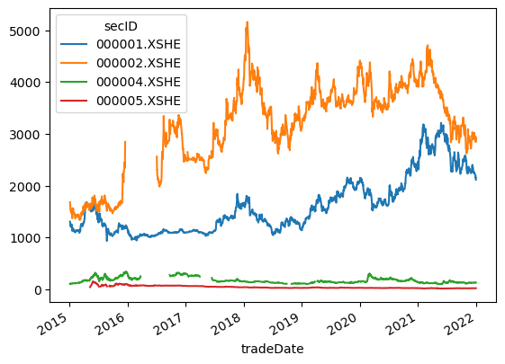

```python
df.reset_index().pivot(index='tradeDate',columns='secID',values='closePrice').iloc[:,0:4].plot()
```

# Plotting

- 画图的基础工具是 Matplotlib
- Matplotlib 可以做精细的操作，但很多时候我们不想事必躬亲，或者我们想先快速地获得一个还不错的图，需要时再微调
- pandas内置可以画图。更复杂的可以用Seaborn(构建于Matplotlib之上)
- 其他常见的画图包：plotly, ggplot, bokeh, etc.

## Matplotlib basics

```python
import matplotlib as mpl
import matplotlib.pyplot as plt
```

axes: 执行画图的instance，子图

axis: x, y

为什么只画一个图的时候，也经常看到写`fig, ax = plt.subplots()`？

因为通常画图时候需要保存。

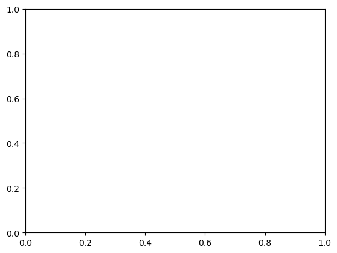

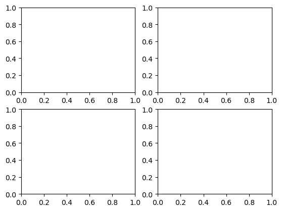

```python
fig = plt.figure()  # an empty figure with no Axes
fig, ax = plt.subplots()  # a figure with a single Axes
fig, axs = plt.subplots(2, 2)  # a figure with a 2x2 grid of Axes
```

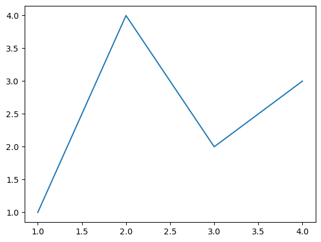

```python
fig, ax = plt.subplots()
ax.plot([1, 2, 3, 4], [1, 4, 2, 3])
```

```python
temp2
```

|  | date | variable | value | value2 |
| --- | --- | --- | --- | --- |
| 0 | 2000-01-03 | A | 1.314670 | 1.728358 |
| 1 | 2000-01-04 | A | -1.281146 | 1.641335 |
| 2 | 2000-01-05 | A | -0.627046 | 0.393187 |
| 3 | 2000-01-03 | B | -1.439479 | 2.072100 |
| 4 | 2000-01-04 | B | 0.317622 | 0.100884 |
| 5 | 2000-01-05 | B | 0.507325 | 0.257379 |
| 6 | 2000-01-03 | C | -0.400497 | 0.160398 |
| 7 | 2000-01-04 | C | 0.562698 | 0.316629 |
| 8 | 2000-01-05 | C | 0.230216 | 0.053000 |
| 9 | 2000-01-03 | D | -0.759633 | 0.577043 |
| 10 | 2000-01-04 | D | 1.176647 | 1.384498 |
| 11 | 2000-01-05 | D | 1.652183 | 2.729708 |

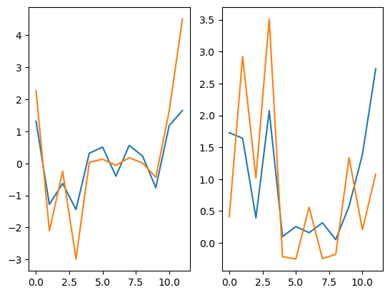

```python
fig, axs = plt.subplots(1,2)
x = range(temp2.shape[0])
y1 = temp2['value']
y2 = temp2['value']**2
axs[0].plot(x, y1)
axs[1].plot(x, y2)
axs[0].plot(x, y1**3)
axs[1].plot(x, y2-y1)
```

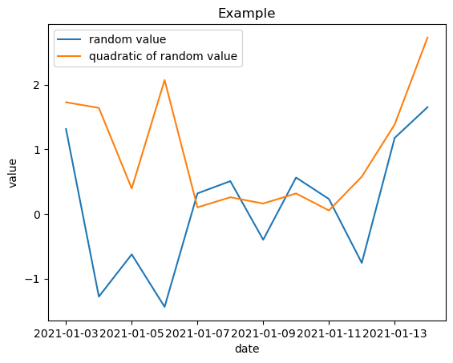

```python
x = pd.date_range(start='2021-01-03',periods=temp2.shape[0])
plt.plot(x,temp2['value'], label='random value')
plt.plot(x,temp2['value']**2, label='quadratic of random value')
plt.xlabel('date')
plt.ylabel('value')
plt.title('Example')
plt.legend()
```

## an Seaborn example with masked data

```python
df_pingan.select_dtypes(np.number).corr()
```

|  | preClosePrice | closePrice | turnoverVol | turnoverValue | dealAmount | turnoverRate | negMarketValue | marketValue |
| --- | --- | --- | --- | --- | --- | --- | --- | --- |
| preClosePrice | 1.000000 | 0.997575 | 0.064982 | 0.389881 | 0.601451 | -0.039942 | 0.989830 | 0.994295 |
| closePrice | 0.997575 | 1.000000 | 0.075458 | 0.400851 | 0.606522 | -0.030710 | 0.991942 | 0.996452 |
| turnoverVol | 0.064982 | 0.075458 | 1.000000 | 0.924077 | 0.752066 | 0.981827 | 0.027619 | 0.055961 |
| turnoverValue | 0.389881 | 0.400851 | 0.924077 | 1.000000 | 0.914040 | 0.862471 | 0.355060 | 0.383088 |
| dealAmount | 0.601451 | 0.606522 | 0.752066 | 0.914040 | 1.000000 | 0.665757 | 0.573258 | 0.596717 |
| turnoverRate | -0.039942 | -0.030710 | 0.981827 | 0.862471 | 0.665757 | 1.000000 | -0.090386 | -0.050985 |
| negMarketValue | 0.989830 | 0.991942 | 0.027619 | 0.355060 | 0.573258 | -0.090386 | 1.000000 | 0.993615 |
| marketValue | 0.994295 | 0.996452 | 0.055961 | 0.383088 | 0.596717 | -0.050985 | 0.993615 | 1.000000 |

```python
corr = df_pingan.select_dtypes(np.number).corr()
```

```python
corr
```

|  | preClosePrice | closePrice | turnoverVol | turnoverValue | dealAmount | turnoverRate | negMarketValue | marketValue |
| --- | --- | --- | --- | --- | --- | --- | --- | --- |
| preClosePrice | 1.000000 | 0.997575 | 0.064982 | 0.389881 | 0.601451 | -0.039942 | 0.989830 | 0.994295 |
| closePrice | 0.997575 | 1.000000 | 0.075458 | 0.400851 | 0.606522 | -0.030710 | 0.991942 | 0.996452 |
| turnoverVol | 0.064982 | 0.075458 | 1.000000 | 0.924077 | 0.752066 | 0.981827 | 0.027619 | 0.055961 |
| turnoverValue | 0.389881 | 0.400851 | 0.924077 | 1.000000 | 0.914040 | 0.862471 | 0.355060 | 0.383088 |
| dealAmount | 0.601451 | 0.606522 | 0.752066 | 0.914040 | 1.000000 | 0.665757 | 0.573258 | 0.596717 |
| turnoverRate | -0.039942 | -0.030710 | 0.981827 | 0.862471 | 0.665757 | 1.000000 | -0.090386 | -0.050985 |
| negMarketValue | 0.989830 | 0.991942 | 0.027619 | 0.355060 | 0.573258 | -0.090386 | 1.000000 | 0.993615 |
| marketValue | 0.994295 | 0.996452 | 0.055961 | 0.383088 | 0.596717 | -0.050985 | 0.993615 | 1.000000 |

```python
np.ones_like?
```

```
Signature: np.ones_like(a, dtype=None, order='K', subok=True, shape=None)
Docstring:
Return an array of ones with the same shape and type as a given array.

Parameters
----------
a : array_like
    The shape and data-type of `a` define these same attributes of
    the returned array.
dtype : data-type, optional
    Overrides the data type of the result.

    .. versionadded:: 1.6.0
order : {'C', 'F', 'A', or 'K'}, optional
    Overrides the memory layout of the result. 'C' means C-order,
    'F' means F-order, 'A' means 'F' if `a` is Fortran contiguous,
    'C' otherwise. 'K' means match the layout of `a` as closely
    as possible.

    .. versionadded:: 1.6.0
subok : bool, optional.
    If True, then the newly created array will use the sub-class
    type of `a`, otherwise it will be a base-class array. Defaults
    to True.
shape : int or sequence of ints, optional.
    Overrides the shape of the result. If order='K' and the number of
    dimensions is unchanged, will try to keep order, otherwise,
    order='C' is implied.

    .. versionadded:: 1.17.0

Returns
-------
out : ndarray
    Array of ones with the same shape and type as `a`.

See Also
--------
empty_like : Return an empty array with shape and type of input.
zeros_like : Return an array of zeros with shape and type of input.
full_like : Return a new array with shape of input filled with value.
ones : Return a new array setting values to one.

Examples
--------
>>> x = np.arange(6)
>>> x = x.reshape((2, 3))
>>> x
array([[0, 1, 2],
       [3, 4, 5]])
>>> np.ones_like(x)
array([[1, 1, 1],
       [1, 1, 1]])

>>> y = np.arange(3, dtype=float)
>>> y
array([0., 1., 2.])
>>> np.ones_like(y)
array([1.,  1.,  1.])
File:      ~/opt/anaconda3/lib/python3.9/site-packages/numpy/core/numeric.py
Type:      function
```

```python
np.ones_like(corr, dtype=bool)
```

```
array([[ True,  True,  True,  True,  True,  True,  True,  True],
       [ True,  True,  True,  True,  True,  True,  True,  True],
       [ True,  True,  True,  True,  True,  True,  True,  True],
       [ True,  True,  True,  True,  True,  True,  True,  True],
       [ True,  True,  True,  True,  True,  True,  True,  True],
       [ True,  True,  True,  True,  True,  True,  True,  True],
       [ True,  True,  True,  True,  True,  True,  True,  True],
       [ True,  True,  True,  True,  True,  True,  True,  True]])
```

```python
np.triu?
```

```
Signature: np.triu(m, k=0)
Docstring:
Upper triangle of an array.

Return a copy of an array with the elements below the `k`-th diagonal
zeroed. For arrays with ``ndim`` exceeding 2, `triu` will apply to the
final two axes.

Please refer to the documentation for `tril` for further details.

See Also
--------
tril : lower triangle of an array

Examples
--------
>>> np.triu([[1,2,3],[4,5,6],[7,8,9],[10,11,12]], -1)
array([[ 1,  2,  3],
       [ 4,  5,  6],
       [ 0,  8,  9],
       [ 0,  0, 12]])

>>> np.triu(np.arange(3*4*5).reshape(3, 4, 5))
array([[[ 0,  1,  2,  3,  4],
        [ 0,  6,  7,  8,  9],
        [ 0,  0, 12, 13, 14],
        [ 0,  0,  0, 18, 19]],
       [[20, 21, 22, 23, 24],
        [ 0, 26, 27, 28, 29],
        [ 0,  0, 32, 33, 34],
        [ 0,  0,  0, 38, 39]],
       [[40, 41, 42, 43, 44],
        [ 0, 46, 47, 48, 49],
        [ 0,  0, 52, 53, 54],
        [ 0,  0,  0, 58, 59]]])
File:      ~/opt/anaconda3/lib/python3.9/site-packages/numpy/lib/twodim_base.py
Type:      function
```

```python
# Generate a mask for the upper triangle
mask = np.triu(np.ones_like(corr, dtype=bool))
```

```python
mask
```

```
array([[ True,  True,  True,  True,  True,  True,  True,  True],
       [False,  True,  True,  True,  True,  True,  True,  True],
       [False, False,  True,  True,  True,  True,  True,  True],
       [False, False, False,  True,  True,  True,  True,  True],
       [False, False, False, False,  True,  True,  True,  True],
       [False, False, False, False, False,  True,  True,  True],
       [False, False, False, False, False, False,  True,  True],
       [False, False, False, False, False, False, False,  True]])
```

```python
import seaborn as sns
```

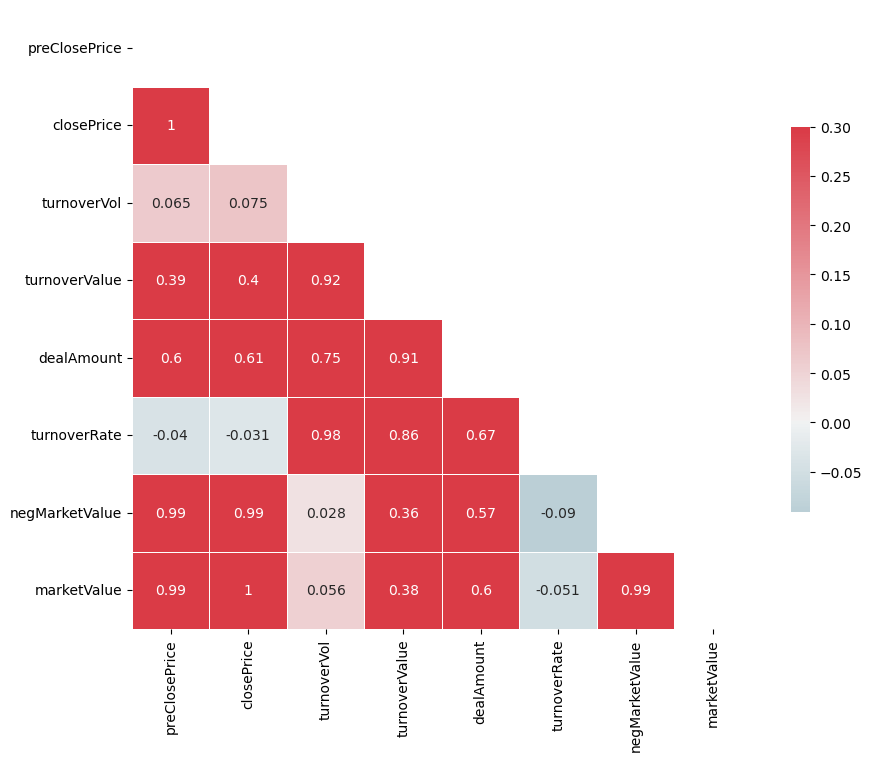

```python
# Set up the matplotlib figure
fig, ax = plt.subplots(figsize=(10, 10))

# Generate a custom diverging colormap
cmap = sns.diverging_palette(220, 10, as_cmap=True)

# Draw the heatmap with the mask and correct aspect ratio
sns.heatmap(corr, mask=mask, cmap=cmap, vmax=.3, center=0, annot=True,
            square=True, linewidths=.5, annot_kws={"size": 10},cbar_kws={"shrink": .5})
```

## Draw from pandas

```python
df_pingan_num = df_pingan.select_dtypes(np.number)
```

```python
df_pingan_num
```

| tradeDate | preClosePrice | closePrice | turnoverVol | turnoverValue | dealAmount | turnoverRate | negMarketValue | marketValue |
| --- | --- | --- | --- | --- | --- | --- | --- | --- |
| 2015-01-05 | 1293.044 | 1307.737 | 4966040 | 4.565388e+09 | 92478.0 | 0.0291 | 1.575841e+11 | 1.830268e+11 |
| 2015-01-06 | 1307.737 | 1288.146 | 3761152 | 3.453446e+09 | 80325.0 | 0.0220 | 1.552233e+11 | 1.802848e+11 |
| 2015-01-07 | 1288.146 | 1263.656 | 2951601 | 2.634796e+09 | 72697.0 | 0.0173 | 1.522723e+11 | 1.768574e+11 |
| 2015-01-08 | 1263.656 | 1221.208 | 2443951 | 2.128003e+09 | 68734.0 | 0.0143 | 1.471572e+11 | 1.709164e+11 |
| 2015-01-09 | 1221.208 | 1231.004 | 4355039 | 3.835378e+09 | 99882.0 | 0.0255 | 1.483376e+11 | 1.722874e+11 |
| ... | ... | ... | ... | ... | ... | ... | ... | ... |
| 2021-12-27 | 2224.866 | 2213.298 | 881462 | 1.260455e+09 | 66911.0 | 0.0038 | 3.341671e+11 | 3.341699e+11 |
| 2021-12-28 | 2213.298 | 2206.872 | 1358314 | 1.934461e+09 | 89671.0 | 0.0058 | 3.331968e+11 | 3.331996e+11 |
| 2021-12-29 | 2206.872 | 2152.889 | 1771527 | 2.480535e+09 | 147243.0 | 0.0076 | 3.250464e+11 | 3.250491e+11 |
| 2021-12-30 | 2152.889 | 2161.886 | 960485 | 1.342374e+09 | 66792.0 | 0.0041 | 3.264048e+11 | 3.264075e+11 |
| 2021-12-31 | 2161.886 | 2118.185 | 2110777 | 2.899617e+09 | 152423.0 | 0.0090 | 3.198068e+11 | 3.198095e+11 |

1705 rows × 8 columns

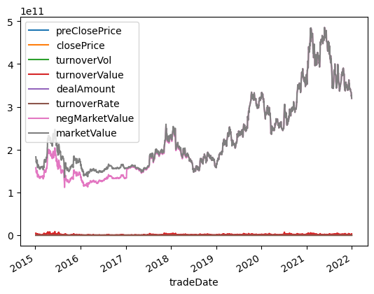

```python
df_pingan_num.plot()
```

```python
plt.rcParams['figure.figsize'] = (16.0, 9.0)
```

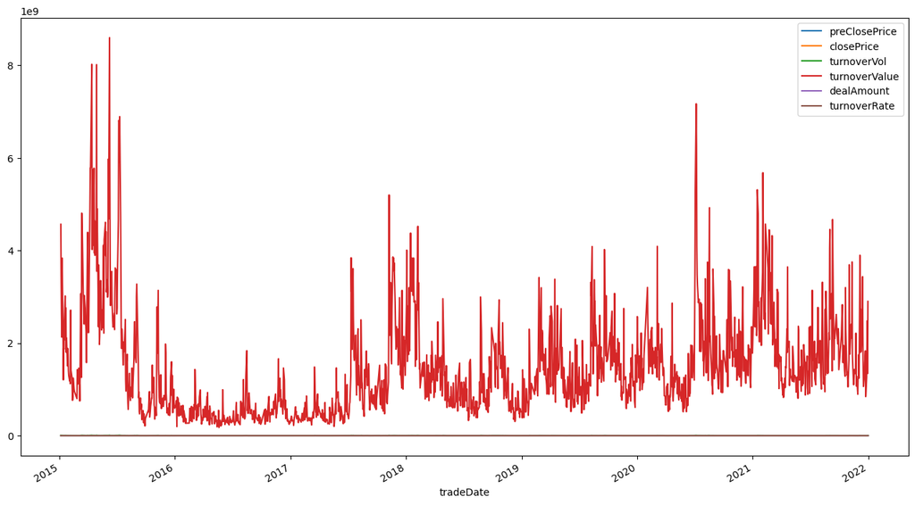

```python
df_pingan_num.drop(['negMarketValue','marketValue'],axis=1).plot()
```

```python
def standardization(col):
    return (col - col.mean()) / col.std()
```

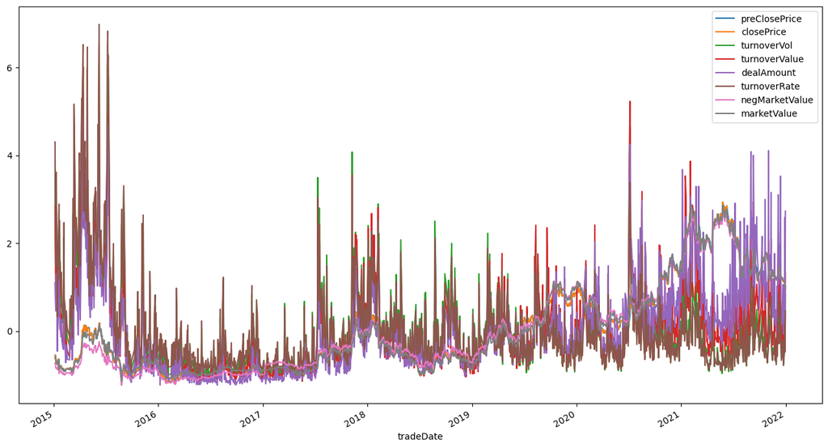

```python
df_pingan_num.apply(standardization).plot()
```

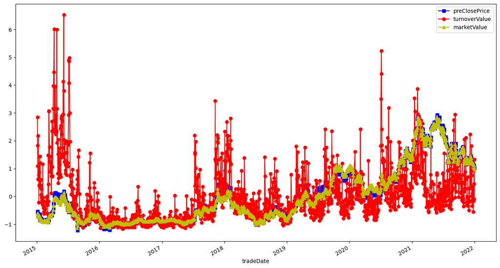

```python
df_pingan_num.apply(standardization)[['preClosePrice','turnoverValue','marketValue']].plot(style=['bs-', 'ro-', 'y^-'])
```

```
array([<AxesSubplot: xlabel='tradeDate'>,
       <AxesSubplot: xlabel='tradeDate'>,
       <AxesSubplot: xlabel='tradeDate'>,
       <AxesSubplot: xlabel='tradeDate'>,
       <AxesSubplot: xlabel='tradeDate'>,
       <AxesSubplot: xlabel='tradeDate'>,
       <AxesSubplot: xlabel='tradeDate'>,
       <AxesSubplot: xlabel='tradeDate'>], dtype=object)
```

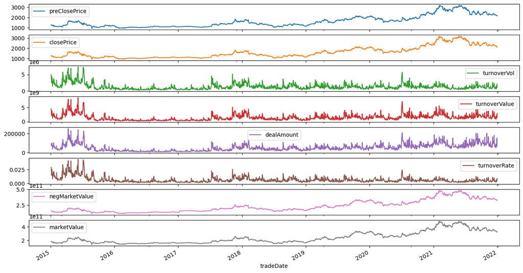

```python
df_pingan_num.plot(subplots=True)
```